# ELISA analysis

Zehao Wu

2026-04-19

# First time run order: Spleen → CBC → ELISA

# Requires clean_meta_data.csv from the spleen analysis file.

# Loading the libraries

```r
library(tidyverse)
library(readxl)
library(writexl)
library(janitor)
library(factoextra)
library(skimr)
library(naniar)
```

```r
library(ggplot2)
library(ggpubr)
library(emmeans)
library(lme4)
library(lmerTest)
library(scales)
library(haven)
library(broom.mixed)
library(readr)
library(here)
library(DHARMa)
library(rstatix)
library(kableExtra)
library(sjPlot) # does not work when knitting to PDF
```

# Setting the paths

```r
base_path <- "/Users/zehao/Documents/Research Projects/Graham Group Thesis Research (Summer 2025)"

data_path <- file.path(base_path, "Metadata", "elisadata")

clean_data_path <- file.path(base_path, "Cleaned data")

figure_path       <- file.path(base_path, "Figures")
elisa_figure_path <- file.path(figure_path, "ELISA Figures")
dir.create(elisa_figure_path, showWarnings = FALSE, recursive = TRUE)
```

# Setting up the functions for repeated codes

# Mean calculator

```r
mean_calculator <- function(input_data,
                            final_concentration,
                            cv_data,
                            groupings = c("mouse_id",
                                          "treatment",
                                          "plate",
                                          "strain",
                                          "t_muris_dose",
                                          "lab_or_rw",
                                          "cohort",
                                          "experiment",
                                          "source",
                                          "experiment_day")) {
input_data %>%
  group_by(across(all_of(groupings))) %>%
  summarize(
    mean_concentration = mean({{final_concentration}},
                    na.rm = TRUE),
    cv_percent = first(na.omit({{cv_data}})),
    .groups = "drop"
  )}
```

# Setting the colors (Okabe-Ito palette and Paul Tol’s Bright)

```r
color_black <- "#000000"
color_mustard <- "#E69F00"
color_light_blue <- "#56B4E9"
color_green <- "#009E73"
color_yellow <- "#F0E442"
color_dark_blue <- "#0072B2"
color_orange <- "#D55E00"
color_purple <- "#CC79A7"

color_grey <- "#BBBBBB"
color_dark_purple <- "#AA3377"
color_light_purple <- "#EE6677"
color_sand <- "#CCBB44"
color_cyan <- "#66CCEE"
color_olive <- "#228833"
color_navy <- "#4477AA"
```

# Basic elisa summary plotter

```r
elisa_summary_plotter <- function(input_data,
                                  y_label,
                                  title = NULL) {
  ggplot(input_data %>% mutate(treatment = factor(treatment, levels = c("IgG", "LPS", "CD28")),
                               lab_or_rw = factor(lab_or_rw, levels = c("Lab", "RW")),
                               t_muris_dose = factor(t_muris_dose, levels = c("Zero", "High"))),
         aes(x = lab_or_rw,
             y = mean_concentration,
             fill = t_muris_dose)) +
    geom_boxplot(position = position_dodge(width = 0.75),
               alpha = 0.8,
               outlier.shape = NA,
               width = 0.5,
               color = "black",
               linewidth = 0.6) +
    geom_jitter(position = position_jitterdodge(jitter.width = 0.15,
                                              dodge.width = 0.75),
              alpha = 0.8,
              size = 1.8,
              shape = 21,
              color = "black") +
    facet_wrap(~ treatment,
               labeller = as_labeller(c("CD28" = "CD28SA",
                                        "LPS" = "LPS",
                                        "IgG" = "IgG1"))) +
    scale_fill_manual(values = c("Zero" = color_dark_blue,
                                 "High" = color_orange),
                    name = expression(bolditalic("T. muris") ~ bold("Dose"))) +
    scale_x_discrete(labels = c("Lab" = "Lab",
                                "RW"  = "Rewilded"),
                     name = expression(bold("Environment"))) +
    scale_y_continuous(expand = expansion(mult = c(0.05, 0.3))) +
    theme_minimal() +
    theme(strip.background = element_rect(fill = "white",
                                        color = "black",
                                        linewidth = 0.8),
        strip.text = element_text(size = 10,
                                  face = "bold"),
        panel.border = element_rect(color = "black",
                                    fill = NA,
                                    linewidth = 0.8),
        panel.grid = element_blank(),
        axis.title.x = element_text(face = "bold"),
        axis.title.y = element_text(face = "bold"),
        axis.text = element_text(color = "black"),
        axis.ticks = element_line(color = "black",
                                  linewidth = 0.3),
        axis.ticks.length = unit(0.15, "cm"),
        plot.title = element_text(hjust = 0.5, face = "bold")) +
    ylab(y_label) +
    ggtitle(title)
}
```

# Treatment specific plotter

```r
elisa_treatment_plotter <- function(input_data,
                                   y_label,
                                   title = NULL) {
  ggplot(input_data %>% mutate(lab_or_rw = factor(lab_or_rw, levels = c("Lab", "RW")),
                               t_muris_dose = factor(t_muris_dose, levels = c("Zero", "High"))),
         aes(x = lab_or_rw,
             y = mean_concentration,
             fill = t_muris_dose)) +
    geom_boxplot(alpha = 0.8,
                 outlier.shape = NA,
                 width = 0.5,
                 color = "black",
                 linewidth = 0.6,
                 position = position_dodge(width = 0.6)) +
    geom_jitter(alpha = 0.8,
                size = 1.8,
                shape = 21,
                color = "black",
                position = position_jitterdodge(jitter.width = 0.1,
                                                dodge.width = 0.6)) +
    scale_fill_manual(values = c("Zero" = color_dark_blue,
                                 "High" = color_orange),
                    name = expression(bolditalic("T. muris") ~ bold("Dose"))) +
    scale_x_discrete(labels = c("Lab" = "Lab",
                                "RW"  = "Rewilded"),
                     name = expression(bold("Environment"))) +
    scale_y_continuous(expand = expansion(mult = c(0.05, 0.3))) +
    theme_minimal() +
    theme(panel.border = element_rect(color = "black",
                                    fill = NA,
                                    linewidth = 0.8),
        panel.grid = element_blank(),
        axis.title.x = element_text(face = "bold"),
        axis.title.y = element_text(face = "bold"),
        axis.text = element_text(color = "black"),
        axis.ticks = element_line(color = "black",
                                  linewidth = 0.3),
        axis.ticks.length = unit(0.15, "cm"),
        plot.title = element_text(hjust = 0.5, face = "bold")) +
    ylab(y_label) +
    ggtitle(title)
}
```

# Emmeans per treatment data frame maker

# NOTE: emm_treatment function was removed — it contained a bug where

# filter(treatment == treatment) compared the column to itself (always TRUE).

# The function was never called anywhere, so it was dead code.

# Plot saver

```r
plot_saver <- function(filename,
                            plot,
                            path = elisa_figure_path,
                            width = 6,
                            height = 4,
                            dpi = 300) {
  ggsave(filename = filename,
       plot = plot,
       path = path,
       width = width,
       height = height,
       units = "in",
       dpi = dpi)
}

svg_saver <- function(filename,
                      plot,
                      path = elisa_figure_path,
                      width = 6,
                      height = 4) {
  ggsave(filename = filename,
         plot = plot,
         path = path,
         width = width,
         height = height,
         units = "in",
         device = "svg")
}
```

## Loading the data

```r
elisa_ifn_1 <- read_xlsx(file.path(data_path,
                                   "IFNg_Plate1_20260121.xlsx"),
                         sheet = "Plate 1 Data")

elisa_ifn_2 <- read_xlsx(file.path(data_path,
                                   "IFNg_Plate2_20260123.xlsx"),
                         sheet = "Plate 2 Data")

elisa_tnf_1 <- read_xlsx(file.path(data_path,
                                   "TNFa_Plate1_20260121.xlsx"),
                         sheet = "Plate 1 Data")

elisa_tnf_2 <- read_xlsx(file.path(data_path,
                                   "TNFa_Plate2_20260123.xlsx"),
                         sheet = "Plate 2 Data")

plate1_map <- read_xlsx(file.path(data_path,
                                  "SF ELISA Plate Mapping.xlsx"),
                        sheet = "Plate 1 for both IFN and TNF")

plate2_map <- read_xlsx(file.path(data_path,
                                  "SF ELISA Plate Mapping.xlsx"),
                        sheet = "Plate 2 for both IFN and TNF")

meta_data <- read_csv(file.path(clean_data_path,
                                "clean_meta_data.csv"))
clean_worm_burden <- read_csv(file.path(clean_data_path,
                                        "clean_worm_burden.csv"))
```

# data cleaning and organization

# Four original cell culture plates, each stimulated on a different day:

# Original plate 1 stimulated July 22, 2025 -> experiment_day = 1

# Original plate 2 stimulated July 23, 2025 -> experiment_day = 2

# Original plate 3 stimulated July 29, 2025 -> experiment_day = 3

# Original plate 4 stimulated July 30, 2025 -> experiment_day = 4

# Each mouse appears on exactly one stimulation plate (one experiment_day).

# For ELISA detection, original plates were combined into 2 detection plates:

# Detection plate 1 = original plates 1 + 2 (July 22 + 23)

# Detection plate 2 = original plates 3 + 4 (July 29 + 30)

# The detection plate number is coded as `plate` in the cleaning chunks below.

# experiment_day (1-4) must be added as a column in the plate map Excel files

# so that it joins in automatically via left_join(plate1_map/plate2_map).

# ifn data cleaning for plate 1

```r
clean_ifn_1 <- elisa_ifn_1 %>%
  clean_names() %>%
  rename("final_ifn" = "final_if_ng") %>% # cleaner names
  left_join(plate1_map,  by = "well_id") %>% # join elisa data and mouse number using plate number
  mutate(plate = 1) %>% # create a new column to signal that this is plate 1
  left_join(meta_data, by = "mouse_id") %>% # add the rest of the meta data
  mutate(
    across(c(concentration,
             final_ifn, mean,
             std_dev,
             cv_percent),
            # apply the same transformation across these columns
           ~ case_when(
              # ~ is like a mini function. case when is checking for a condition and applying the first operation if the first condition matches.
             str_detect(., "^<") ~ 0,
             # . is the current value in the column and the rest of the function is asking if this value starts with a <. If yes, then replace it with 0. This is just turning all the <0.0000 values into actual numbers of 0.
             TRUE ~ as.numeric(str_remove(., "^>"))
           )) # the TRUE means that if none of the previous conditinos matched, then do these. Same logic applies where we remove > from values if present. The as numeric converts the text to number.
  ) %>%
  drop_na(mouse_id)
```

# ifn data cleaning for plate 2

```r
clean_ifn_2 <- elisa_ifn_2 %>% #same as before...
  clean_names() %>%
  rename("final_ifn" = "final_if_ng") %>%
  left_join(plate2_map,  by = "well_id") %>%
  mutate(plate = 2) %>%
  left_join(meta_data, by = "mouse_id") %>%
   mutate(
    across(c(concentration, final_ifn, mean, std_dev, cv_percent),
           ~ case_when(
             str_detect(., "^<") ~ 0,
             TRUE ~ as.numeric(str_remove(., "^>"))
           ))
  ) %>%
  drop_na(mouse_id)
total_ifn <- bind_rows(clean_ifn_1,
                       clean_ifn_2)

write_csv(total_ifn, file.path(clean_data_path, "combined_ifn_elisa_data.csv"))
```

For now, I just kept all of the values that are over the detection limit without their “>” and all of the small values as zero. Discuss with David.

# tnf data cleaning for plate 1

```r
clean_tnf_1 <- elisa_tnf_1 %>% #same as before...
  clean_names() %>%
  rename("final_tnf" = "concentration") %>%
  left_join(plate1_map,  by = "well_id") %>%
  mutate(plate = 1) %>%
  left_join(meta_data, by = "mouse_id") %>%
   mutate(
    across(c(final_tnf, mean, std_dev, cv_percent),
           ~ case_when(
             str_detect(., "^<") ~ 0,
             TRUE ~ as.numeric(str_remove(., "^>"))
           ))
  ) %>%
  drop_na(mouse_id)
```

# tnf data cleaning for plate 2

```r
clean_tnf_2 <- elisa_tnf_2 %>% #same as before...
  clean_names() %>%
  rename("final_tnf" = "concentration") %>%
  left_join(plate2_map,  by = "well_id") %>%
  mutate(plate = 2) %>%
  left_join(meta_data, by = "mouse_id") %>%
   mutate(
    across(c(final_tnf, mean, std_dev, cv_percent),
           ~ case_when(
             str_detect(., "^<") ~ 0,
             TRUE ~ as.numeric(str_remove(., "^>"))
           ))
  ) %>%
  drop_na(mouse_id)
total_tnf <- bind_rows(clean_tnf_1,
                       clean_tnf_2)

write_csv(total_tnf, file.path(clean_data_path,
                               "combined_tnf_elisa_data.csv"))
```

# Calculating the mean concentration value

```r
ifn_input <- mean_calculator(total_ifn,
                             final_ifn,
                             cv_percent) %>%
  mutate(treatment = factor(treatment, levels = c("CD28", "LPS", "IgG")))

tnf_input <- mean_calculator(total_tnf,
                             final_tnf,
                             cv_percent) %>%
  mutate(treatment = factor(treatment, levels = c("CD28", "LPS", "IgG")))
```

I wonder if I should use the original data points instead of the mean data.

# Sample sizes per group

```r
ifn_sample_counts <- ifn_input %>%
  group_by(strain, lab_or_rw, t_muris_dose, treatment) %>%
  summarise(n = n(), .groups = "drop")

kable(ifn_sample_counts) %>%
  kable_styling(full_width = FALSE)
```

| strain | lab_or_rw | t_muris_dose | treatment | n |
| --- | --- | --- | --- | --- |
| C57BL/6J | Lab | High | CD28 | 6 |
| C57BL/6J | Lab | High | LPS | 6 |
| C57BL/6J | Lab | High | IgG | 6 |
| C57BL/6J | Lab | Zero | CD28 | 9 |
| C57BL/6J | Lab | Zero | LPS | 9 |
| C57BL/6J | Lab | Zero | IgG | 9 |
| C57BL/6J | RW | High | CD28 | 9 |
| C57BL/6J | RW | High | LPS | 9 |
| C57BL/6J | RW | High | IgG | 9 |
| C57BL/6J | RW | Zero | CD28 | 8 |
| C57BL/6J | RW | Zero | LPS | 8 |
| C57BL/6J | RW | Zero | IgG | 8 |

```r
tnf_sample_counts <- tnf_input %>%
  group_by(strain, lab_or_rw, t_muris_dose, treatment) %>%
  summarise(n = n(), .groups = "drop")

kable(tnf_sample_counts) %>%
  kable_styling(full_width = FALSE)
```

| strain | lab_or_rw | t_muris_dose | treatment | n |
| --- | --- | --- | --- | --- |
| C57BL/6J | Lab | High | CD28 | 6 |
| C57BL/6J | Lab | High | LPS | 6 |
| C57BL/6J | Lab | High | IgG | 6 |
| C57BL/6J | Lab | Zero | CD28 | 9 |
| C57BL/6J | Lab | Zero | LPS | 9 |
| C57BL/6J | Lab | Zero | IgG | 9 |
| C57BL/6J | RW | High | CD28 | 9 |
| C57BL/6J | RW | High | LPS | 9 |
| C57BL/6J | RW | High | IgG | 9 |
| C57BL/6J | RW | Zero | CD28 | 8 |
| C57BL/6J | RW | Zero | LPS | 8 |
| C57BL/6J | RW | Zero | IgG | 8 |

# Filter the data for treatment specific plots

```r
ifn_input_cd28 <- ifn_input %>% filter(treatment == "CD28")

ifn_input_lps <- ifn_input %>% filter(treatment == "LPS")

ifn_input_igg <- ifn_input %>% filter(treatment == "IgG")

tnf_input_cd28 <- tnf_input %>% filter(treatment == "CD28")

tnf_input_lps <- tnf_input %>% filter(treatment == "LPS")

tnf_input_igg <- tnf_input %>% filter(treatment == "IgG")
```

# General ifn plot to get an overview

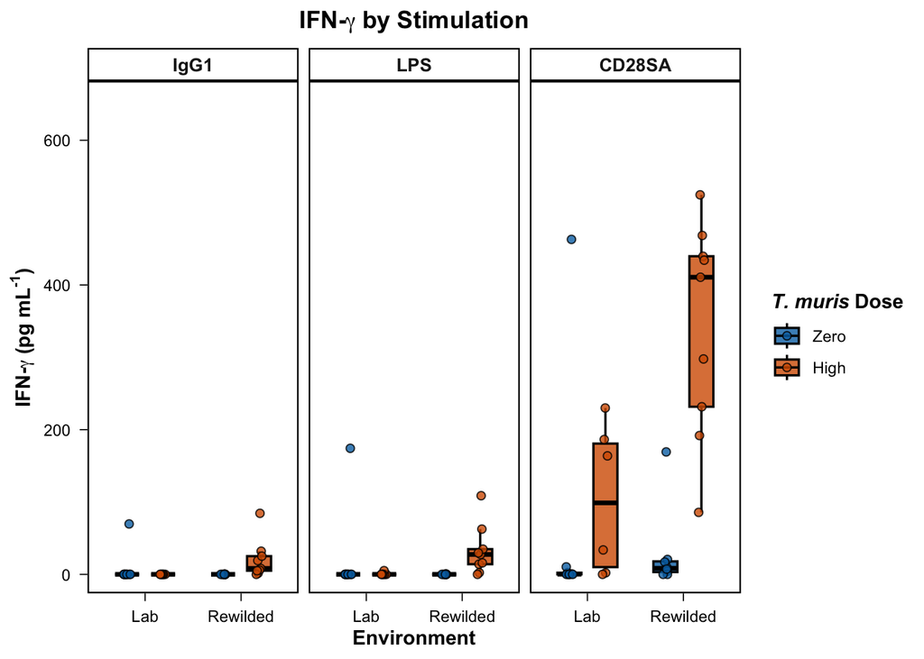

```r
ifn_input <- ifn_input %>%
  mutate(t_muris_dose = factor(t_muris_dose,
                               levels = c("Zero", "High")))

ifn_plot <- elisa_summary_plotter(ifn_input,
                                  expression(bold("IFN-" * gamma ~ "(pg mL"^"-1"*")")),
                                  title = expression(bold("IFN-"*gamma~"by Stimulation")))

ifn_plot
```

```r
plot_saver("general_ifn_plot.png",
           ifn_plot)
svg_saver("general_ifn_plot.svg",
          ifn_plot)
```

# General tnf plots

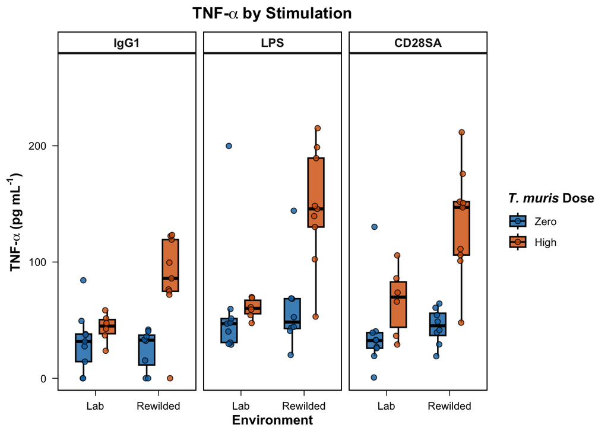

```r
tnf_input <- tnf_input %>%
  mutate(t_muris_dose = factor(t_muris_dose,
                               levels = c("Zero", "High")))

tnf_plot <- elisa_summary_plotter(tnf_input,
                                  expression(bold("TNF-"*alpha ~ "(pg mL"^"-1"*")")),
                                  title = expression(bold("TNF-"*alpha~"by Stimulation")))

tnf_plot
```

```r
plot_saver("general_tnf_plot.png",
           tnf_plot)
svg_saver("general_tnf_plot.svg",
          tnf_plot)
```

# IFN faceted by T. muris dose: treatment on x, environment as color

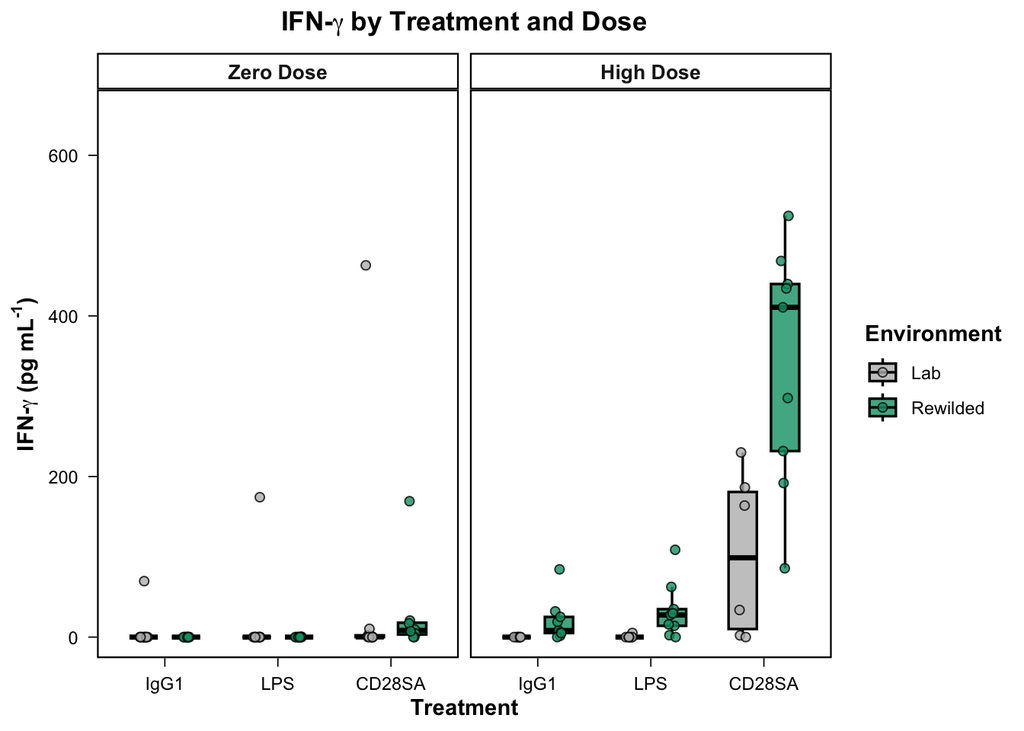

```r
ifn_dose_facet_plot <- ggplot(ifn_input %>%
                                mutate(treatment = factor(treatment,
                                                          levels = c("IgG",
                                                                     "LPS",
                                                                     "CD28"))),
                              aes(x = treatment,
                                  y = mean_concentration,
                                  fill = lab_or_rw)) +
  geom_boxplot(position = position_dodge(width = 0.75),
               alpha = 0.8,
               outlier.shape = NA,
               width = 0.5,
               color = "black",
               linewidth = 0.6) +
  geom_jitter(position = position_jitterdodge(jitter.width = 0.15,
                                              dodge.width = 0.75),
              alpha = 0.8,
              size = 1.8,
              shape = 21,
              color = "black") +
  facet_wrap(~ t_muris_dose,
             labeller = as_labeller(c("Zero" = "Zero Dose",
                                      "High" = "High Dose"))) +
  scale_fill_manual(values = c("Lab" = color_grey,
                               "RW"  = color_green),
                    labels = c("Lab" = "Lab",
                               "RW"  = "Rewilded"),
                    name = expression(bold("Environment"))) +
  scale_x_discrete(name = expression(bold("Treatment")),
                   labels = c("CD28" = "CD28SA",
                              "LPS" = "LPS",
                              "IgG" = "IgG1")) +
  scale_y_continuous(name = expression(bold("IFN-" * gamma ~
                                              "(pg mL"^"-1" * ")")),
                     expand = expansion(mult = c(0.05, 0.3))) +
  theme_minimal() +
  theme(strip.background = element_rect(fill = "white",
                                        color = "black",
                                        linewidth = 0.8),
        strip.text = element_text(size = 10,
                                  face = "bold"),
        panel.border = element_rect(color = "black",
                                    fill = NA,
                                    linewidth = 0.8),
        panel.grid = element_blank(),
        axis.title.x = element_text(face = "bold"),
        axis.title.y = element_text(face = "bold"),
        axis.text = element_text(color = "black"),
        axis.ticks = element_line(color = "black",
                                  linewidth = 0.3),
        axis.ticks.length = unit(0.15, "cm"),
        plot.title = element_text(hjust = 0.5, face = "bold")) +
  ggtitle(expression(bold("IFN-" * gamma ~ "by Treatment and Dose")))

ifn_dose_facet_plot
```

```r
plot_saver("ifn_dose_facet_plot.png",
           ifn_dose_facet_plot)
svg_saver("ifn_dose_facet_plot.svg",
          ifn_dose_facet_plot)
```

# TNF faceted by T. muris dose: treatment on x, environment as color

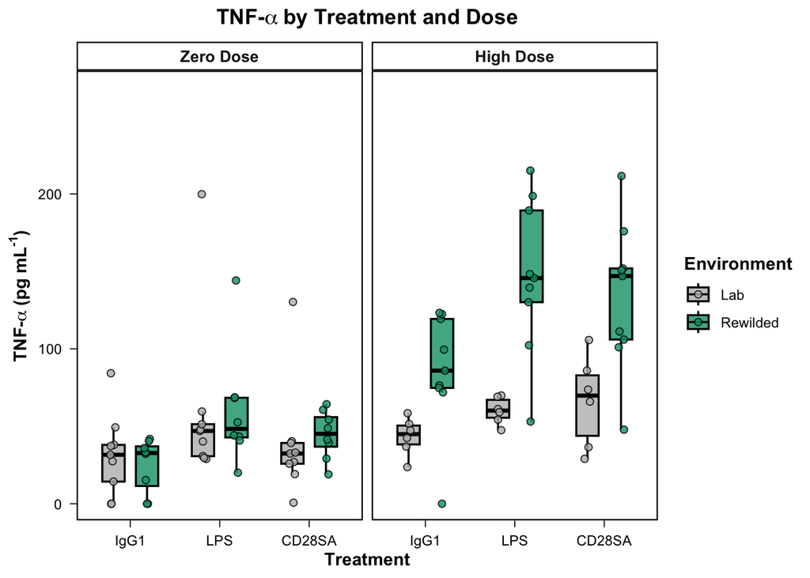

```r
tnf_dose_facet_plot <- ggplot(tnf_input %>%
                                mutate(treatment = factor(treatment,
                                                          levels = c("IgG",
                                                                     "LPS",
                                                                     "CD28"))),
                              aes(x = treatment,
                                  y = mean_concentration,
                                  fill = lab_or_rw)) +
  geom_boxplot(position = position_dodge(width = 0.75),
               alpha = 0.8,
               outlier.shape = NA,
               width = 0.5,
               color = "black",
               linewidth = 0.6) +
  geom_jitter(position = position_jitterdodge(jitter.width = 0.15,
                                              dodge.width = 0.75),
              alpha = 0.8,
              size = 1.8,
              shape = 21,
              color = "black") +
  facet_wrap(~ t_muris_dose,
             labeller = as_labeller(c("Zero" = "Zero Dose",
                                      "High" = "High Dose"))) +
  scale_fill_manual(values = c("Lab" = color_grey,
                               "RW"  = color_green),
                    labels = c("Lab" = "Lab",
                               "RW"  = "Rewilded"),
                    name = expression(bold("Environment"))) +
  scale_x_discrete(name = expression(bold("Treatment")),
                   labels = c("CD28" = "CD28SA",
                              "LPS" = "LPS",
                              "IgG" = "IgG1")) +
  scale_y_continuous(name = expression(bold("TNF-" * alpha ~
                                              "(pg mL"^"-1" * ")")),
                     expand = expansion(mult = c(0.05, 0.3))) +
  theme_minimal() +
  theme(strip.background = element_rect(fill = "white",
                                        color = "black",
                                        linewidth = 0.8),
        strip.text = element_text(size = 10,
                                  face = "bold"),
        panel.border = element_rect(color = "black",
                                    fill = NA,
                                    linewidth = 0.8),
        panel.grid = element_blank(),
        axis.title.x = element_text(face = "bold"),
        axis.title.y = element_text(face = "bold"),
        axis.text = element_text(color = "black"),
        axis.ticks = element_line(color = "black",
                                  linewidth = 0.3),
        axis.ticks.length = unit(0.15, "cm"),
        plot.title = element_text(hjust = 0.5, face = "bold")) +
  ggtitle(expression(bold("TNF-" * alpha ~ "by Treatment and Dose")))

tnf_dose_facet_plot
```

```r
plot_saver("tnf_dose_facet_plot.png",
           tnf_dose_facet_plot)
svg_saver("tnf_dose_facet_plot.svg",
          tnf_dose_facet_plot)
```

# IFN faceted by environment: treatment on x, dose as color (#3)

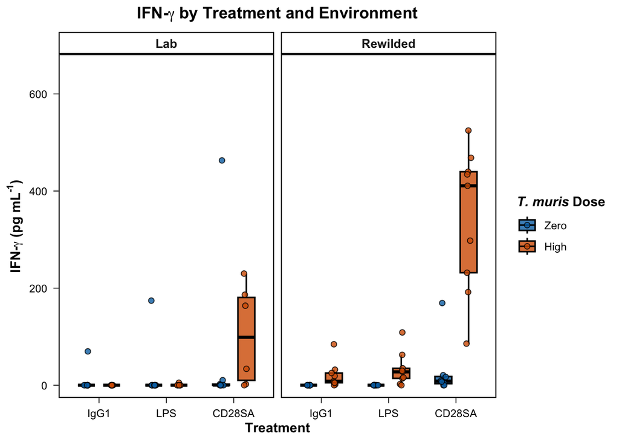

```r
ifn_env_facet_plot <- ggplot(ifn_input %>%
                               mutate(treatment = factor(treatment,
                                                         levels = c("IgG",
                                                                    "LPS",
                                                                    "CD28")),
                                      lab_or_rw = factor(lab_or_rw,
                                                         levels = c("Lab", "RW")),
                                      t_muris_dose = factor(t_muris_dose,
                                                            levels = c("Zero", "High"))),
                             aes(x = treatment,
                                 y = mean_concentration,
                                 fill = t_muris_dose)) +
  geom_boxplot(position = position_dodge(width = 0.75),
               alpha = 0.8,
               outlier.shape = NA,
               width = 0.5,
               color = "black",
               linewidth = 0.6) +
  geom_jitter(position = position_jitterdodge(jitter.width = 0.15,
                                              dodge.width = 0.75),
              alpha = 0.8,
              size = 1.8,
              shape = 21,
              color = "black") +
  facet_wrap(~ lab_or_rw,
             labeller = as_labeller(c("Lab" = "Lab",
                                      "RW"  = "Rewilded"))) +
  scale_fill_manual(values = c("Zero" = color_dark_blue,
                               "High" = color_orange),
                    name = expression(bolditalic("T. muris") ~ bold("Dose"))) +
  scale_x_discrete(name = expression(bold("Treatment")),
                   labels = c("CD28" = "CD28SA",
                              "LPS" = "LPS",
                              "IgG" = "IgG1")) +
  scale_y_continuous(name = expression(bold("IFN-" * gamma ~
                                              "(pg mL"^"-1" * ")")),
                     expand = expansion(mult = c(0.05, 0.3))) +
  theme_minimal() +
  theme(strip.background = element_rect(fill = "white",
                                        color = "black",
                                        linewidth = 0.8),
        strip.text = element_text(size = 10,
                                  face = "bold"),
        panel.border = element_rect(color = "black",
                                    fill = NA,
                                    linewidth = 0.8),
        panel.grid = element_blank(),
        axis.title.x = element_text(face = "bold"),
        axis.title.y = element_text(face = "bold"),
        axis.text = element_text(color = "black"),
        axis.ticks = element_line(color = "black",
                                  linewidth = 0.3),
        axis.ticks.length = unit(0.15, "cm"),
        plot.title = element_text(hjust = 0.5, face = "bold")) +
  ggtitle(expression(bold("IFN-" * gamma ~ "by Treatment and Environment")))

ifn_env_facet_plot
```

```r
plot_saver("ifn_env_facet_plot.png",
           ifn_env_facet_plot)
svg_saver("ifn_env_facet_plot.svg",
          ifn_env_facet_plot)
```

# TNF faceted by environment: treatment on x, dose as color (#3)

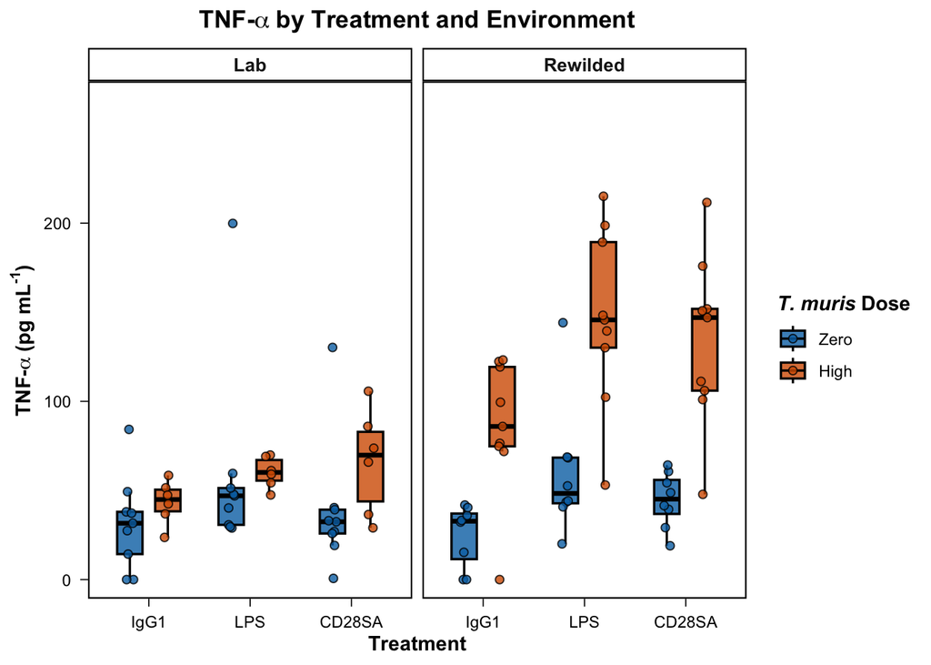

```r
tnf_env_facet_plot <- ggplot(tnf_input %>%
                               mutate(treatment = factor(treatment,
                                                         levels = c("IgG",
                                                                    "LPS",
                                                                    "CD28")),
                                      lab_or_rw = factor(lab_or_rw,
                                                         levels = c("Lab", "RW")),
                                      t_muris_dose = factor(t_muris_dose,
                                                            levels = c("Zero", "High"))),
                             aes(x = treatment,
                                 y = mean_concentration,
                                 fill = t_muris_dose)) +
  geom_boxplot(position = position_dodge(width = 0.75),
               alpha = 0.8,
               outlier.shape = NA,
               width = 0.5,
               color = "black",
               linewidth = 0.6) +
  geom_jitter(position = position_jitterdodge(jitter.width = 0.15,
                                              dodge.width = 0.75),
              alpha = 0.8,
              size = 1.8,
              shape = 21,
              color = "black") +
  facet_wrap(~ lab_or_rw,
             labeller = as_labeller(c("Lab" = "Lab",
                                      "RW"  = "Rewilded"))) +
  scale_fill_manual(values = c("Zero" = color_dark_blue,
                               "High" = color_orange),
                    name = expression(bolditalic("T. muris") ~ bold("Dose"))) +
  scale_x_discrete(name = expression(bold("Treatment")),
                   labels = c("CD28" = "CD28SA",
                              "LPS" = "LPS",
                              "IgG" = "IgG1")) +
  scale_y_continuous(name = expression(bold("TNF-" * alpha ~
                                              "(pg mL"^"-1" * ")")),
                     expand = expansion(mult = c(0.05, 0.3))) +
  theme_minimal() +
  theme(strip.background = element_rect(fill = "white",
                                        color = "black",
                                        linewidth = 0.8),
        strip.text = element_text(size = 10,
                                  face = "bold"),
        panel.border = element_rect(color = "black",
                                    fill = NA,
                                    linewidth = 0.8),
        panel.grid = element_blank(),
        axis.title.x = element_text(face = "bold"),
        axis.title.y = element_text(face = "bold"),
        axis.text = element_text(color = "black"),
        axis.ticks = element_line(color = "black",
                                  linewidth = 0.3),
        axis.ticks.length = unit(0.15, "cm"),
        plot.title = element_text(hjust = 0.5, face = "bold")) +
  ggtitle(expression(bold("TNF-" * alpha ~ "by Treatment and Environment")))

tnf_env_facet_plot
```

```r
plot_saver("tnf_env_facet_plot.png",
           tnf_env_facet_plot)
svg_saver("tnf_env_facet_plot.svg",
          tnf_env_facet_plot)
```

# Treatment specific plots for ifn: CD28

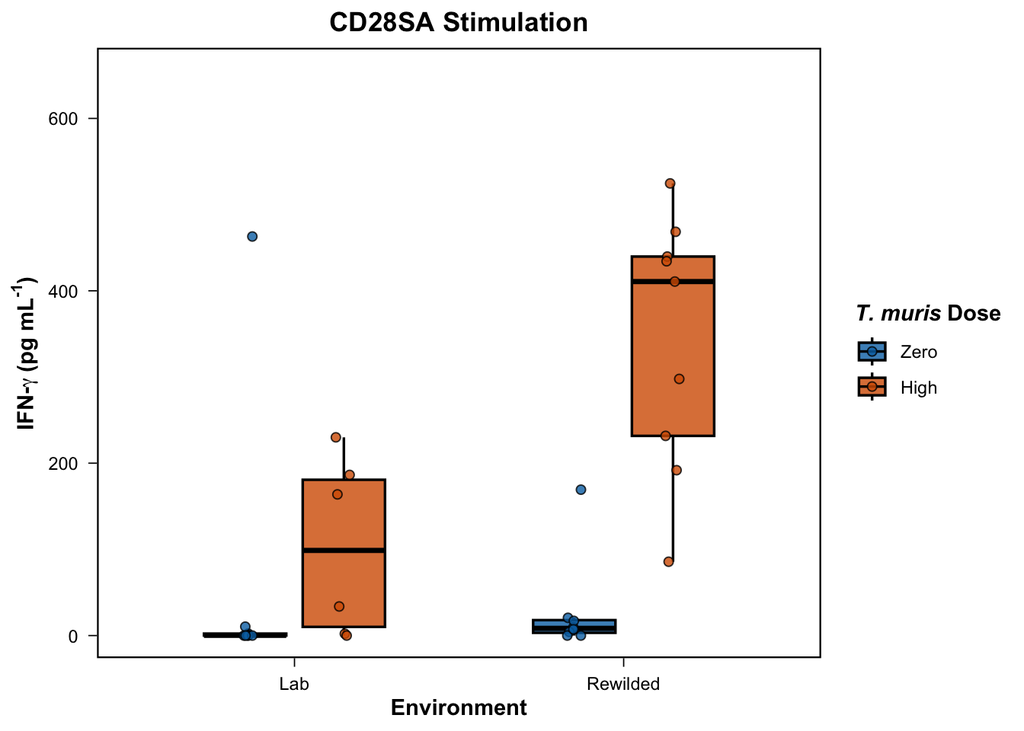

```r
ifn_input_cd28 <- ifn_input_cd28 %>%
  mutate(t_muris_dose = factor(t_muris_dose, levels = c("Zero", "High")))

ifn_cd28_plot <- elisa_treatment_plotter(ifn_input_cd28,
                                       expression(bold("IFN-" * gamma ~ "(pg mL"^"-1"*")")),
                                       title = expression(bold("CD28SA Stimulation")))

ifn_cd28_plot
```

```r
plot_saver("ifn_cd28_treatment_plot.png",
           ifn_cd28_plot)
svg_saver("ifn_cd28_treatment_plot.svg",
          ifn_cd28_plot)
```

# Treatment specific plots for tnf: CD28

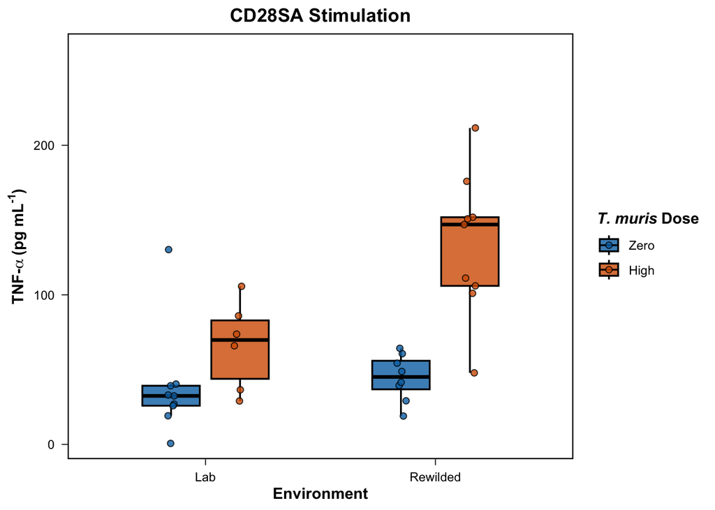

```r
tnf_input_cd28 <- tnf_input_cd28 %>%
  mutate(t_muris_dose = factor(t_muris_dose, levels = c("Zero", "High")))

tnf_cd28_plot <- elisa_treatment_plotter(tnf_input_cd28,
                                       expression(bold("TNF-"*alpha ~ "(pg mL"^"-1"*")")),
                                       title = expression(bold("CD28SA Stimulation")))

tnf_cd28_plot
```

```r
plot_saver("tnf_cd28_treatment_plot.png",
           tnf_cd28_plot)
svg_saver("tnf_cd28_treatment_plot.svg",
          tnf_cd28_plot)
```

# Treatment specific plots for ifn: LPS

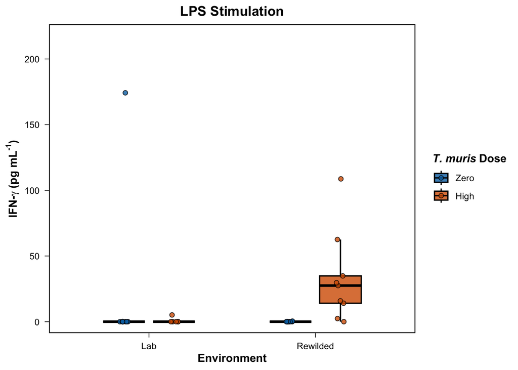

```r
ifn_input_lps <- ifn_input_lps %>%
  mutate(t_muris_dose = factor(t_muris_dose, levels = c("Zero", "High")))

ifn_lps_plot <- elisa_treatment_plotter(ifn_input_lps,
                                       expression(bold("IFN-" * gamma ~ "(pg mL"^"-1"*")")),
                                       title = expression(bold("LPS Stimulation")))

ifn_lps_plot
```

```r
plot_saver("ifn_lps_treatment_plot.png",
           ifn_lps_plot)
svg_saver("ifn_lps_treatment_plot.svg",
          ifn_lps_plot)
```

# Treatment specific plots for tnf: LPS

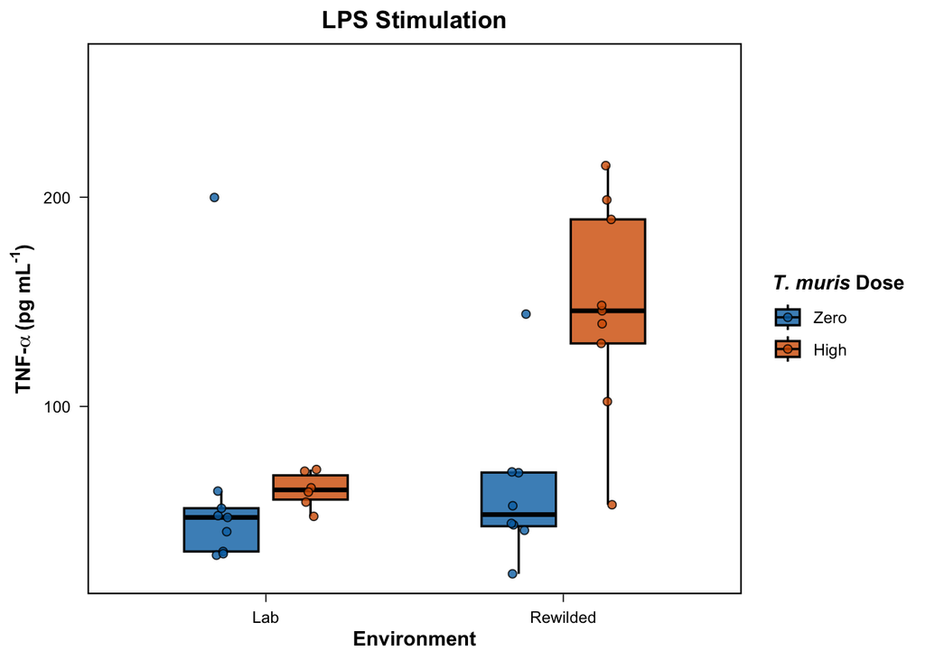

```r
tnf_input_lps <- tnf_input_lps %>%
  mutate(t_muris_dose = factor(t_muris_dose,
                               levels = c("Zero", "High")))

tnf_lps_plot <- elisa_treatment_plotter(tnf_input_lps,
                                       expression(bold("TNF-"*alpha ~ "(pg mL"^"-1"*")")),
                                       title = expression(bold("LPS Stimulation")))

tnf_lps_plot
```

```r
plot_saver("tnf_lps_treatment_plot.png",
           tnf_lps_plot)
svg_saver("tnf_lps_treatment_plot.svg",
          tnf_lps_plot)
```

# Treatment specific plots for ifn: IgG

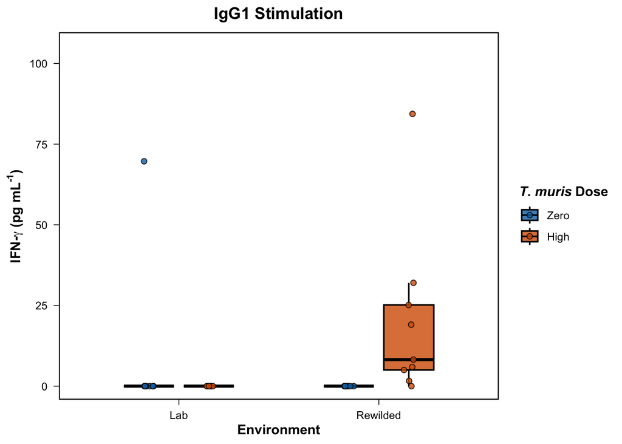

```r
ifn_input_igg <- ifn_input_igg %>%
  mutate(t_muris_dose = factor(t_muris_dose, levels = c("Zero", "High")))

ifn_igg_plot <- elisa_treatment_plotter(ifn_input_igg,
                                       expression(bold("IFN-" * gamma ~ "(pg mL"^"-1"*")")),
                                       title = expression(bold("IgG1 Stimulation")))

ifn_igg_plot
```

```r
plot_saver("ifn_igg_treatment_plot.png",
           ifn_igg_plot)
svg_saver("ifn_igg_treatment_plot.svg",
          ifn_igg_plot)
```

# Treatment specific plots for tnf: IgG

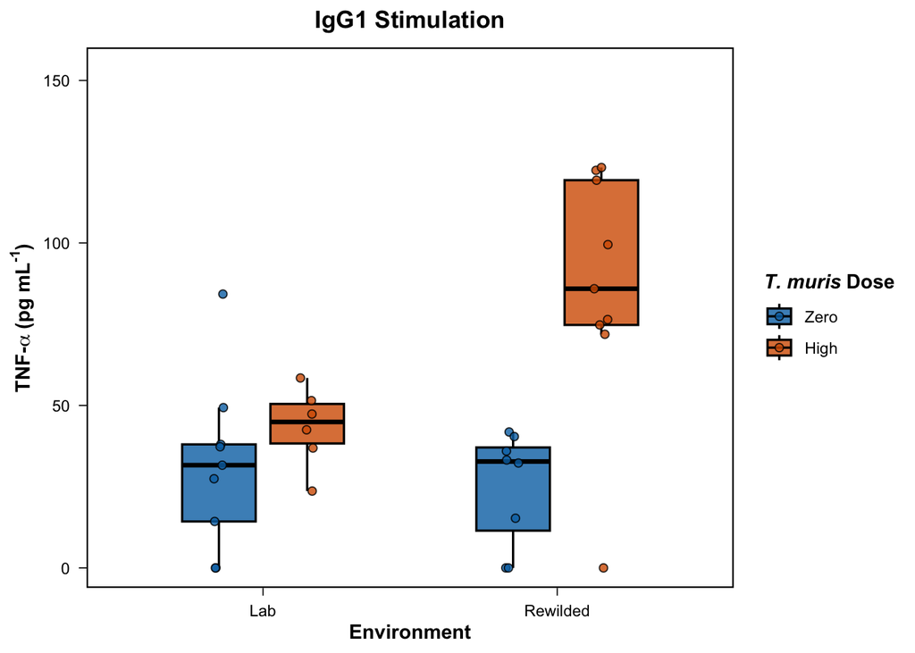

```r
tnf_input_igg <- tnf_input_igg %>%
  mutate(t_muris_dose = factor(t_muris_dose,
                               levels = c("Zero", "High")))

tnf_igg_plot <- elisa_treatment_plotter(tnf_input_igg,
                                       expression(bold("TNF-"*alpha ~ "(pg mL"^"-1"*")")),
                                       title = expression(bold("IgG1 Stimulation")))

tnf_igg_plot
```

```r
plot_saver("tnf_igg_treatment_plot.png",
           tnf_igg_plot)
svg_saver("tnf_igg_treatment_plot.svg",
          tnf_igg_plot)
```

# Setting reference levels for ifn

# Mixed effect model (gamma) for ifn and diagnostics

# Note to self: should I just assume that all zeros are at the detection level?

# Maybe we can just take half of the detection limit (standard practice)

# Detection level for IFN is 1.797 pg/mL so we use this to handle zero values.

```r
ifn_input <- ifn_input %>%
  mutate(
    t_muris_dose = relevel(factor(t_muris_dose), ref = "Zero"),
    treatment = relevel(factor(treatment), ref = "IgG"),
    lab_or_rw = relevel(factor(lab_or_rw), ref = "Lab")
  )

ifn_glmer_input <- ifn_input %>%
  mutate(mean_concentration = ifelse(mean_concentration == 0,
                                     1.797 / 2,
                                     mean_concentration))


ifn_glmer <- glmer(mean_concentration ~ lab_or_rw *
                     t_muris_dose *
                     treatment +
                     (1 | mouse_id) +
                     (1 | experiment_day),
                  family = Gamma(link = "log"),
                  control = glmerControl(optimizer = "bobyqa",
                                         optCtrl = list(maxfun = 2e5)),
                  data = ifn_glmer_input)
```

```
## boundary (singular) fit: see help('isSingular')
```

```r
tab_model(ifn_glmer, show.stat = TRUE)
```

```
## boundary (singular) fit: see help('isSingular')
```

|  | mean concentration |  |  |  |
| --- | --- | --- | --- | --- |
| Predictors | Estimates | CI | Statistic | p |
| (Intercept) | 1.51 | 0.70 – 3.29 | 1.06 | 0.290 |
| lab or rw [RW] | 0.66 | 0.21 – 2.03 | -0.74 | 0.461 |
| t muris dose [High] | 0.66 | 0.19 – 2.25 | -0.68 | 0.501 |
| treatment [CD28] | 2.04 | 1.01 – 4.10 | 2.03 | **0.046** |
| treatment [LPS] | 1.15 | 0.57 – 2.31 | 0.39 | 0.696 |
| lab or rw [RW] × t muris dose [High] | 17.97 | 3.39 – 95.21 | 3.45 | **0.001** |
| lab or rw [RW] × treatment [CD28] | 6.77 | 2.44 – 18.74 | 3.73 | **<0.001** |
| lab or rw [RW] × treatment [LPS] | 0.79 | 0.29 – 2.19 | -0.46 | 0.649 |
| t muris dose [High] × treatment [CD28] | 34.83 | 11.54 – 105.15 | 6.39 | **<0.001** |
| t muris dose [High] × treatment [LPS] | 1.14 | 0.38 – 3.45 | 0.24 | 0.810 |
| (lab or rw [RW] × t muris dose [High]) × treatment [CD28] | 0.06 | 0.01 – 0.27 | -3.73 | **<0.001** |
| (lab or rw [RW] × t muris dose [High]) × treatment [LPS] | 1.79 | 0.40 – 8.03 | 0.77 | 0.445 |
| Random Effects |  |  |  |  |
| σ<sup>2</sup> | 0.44 |  |  |  |
| τ<sub>00</sub> <sub>mouse_id</sub> | 0.81 |  |  |  |
| τ<sub>00</sub> <sub>experiment_day</sub> | 0.00 |  |  |  |
| N <sub>mouse_id</sub> | 32 |  |  |  |
| N <sub>experiment_day</sub> | 4 |  |  |  |
| Observations | 96 |  |  |  |
| Marginal R<sup>2</sup> / Conditional R<sup>2</sup> | 0.887 / NA |  |  |  |

```r
# statistic is t-value btw
summary(ifn_glmer)
```

```
## Generalized linear mixed model fit by maximum likelihood (Laplace
##   Approximation) [glmerMod]
##  Family: Gamma  ( log )
## Formula: mean_concentration ~ lab_or_rw * t_muris_dose * treatment + (1 |
##     mouse_id) + (1 | experiment_day)
##    Data: ifn_glmer_input
## Control: glmerControl(optimizer = "bobyqa", optCtrl = list(maxfun = 2e+05))
##
##       AIC       BIC    logLik -2*log(L)  df.resid
##     605.0     643.5    -287.5     575.0        81
##
## Scaled residuals:
##     Min      1Q  Median      3Q     Max
## -1.3141 -0.6229 -0.0637  0.3756  3.1796
##
## Random effects:
##  Groups         Name        Variance  Std.Dev.
##  mouse_id       (Intercept) 8.113e-01 9.007e-01
##  experiment_day (Intercept) 9.667e-10 3.109e-05
##  Residual                   5.550e-01 7.450e-01
## Number of obs: 96, groups:  mouse_id, 32; experiment_day, 4
##
## Fixed effects:
##                                            Estimate Std. Error t value Pr(>|z|)
## (Intercept)                                  0.4149     0.3896   1.065 0.286938
## lab_or_rwRW                                 -0.4207     0.5680  -0.741 0.458877
## t_muris_doseHigh                            -0.4167     0.6161  -0.676 0.498744
## treatmentCD28                                0.7130     0.3512   2.030 0.042328
## treatmentLPS                                 0.1379     0.3512   0.393 0.694557
## lab_or_rwRW:t_muris_doseHigh                 2.8889     0.8379   3.448 0.000566
## lab_or_rwRW:treatmentCD28                    1.9120     0.5119   3.735 0.000188
## lab_or_rwRW:treatmentLPS                    -0.2341     0.5119  -0.457 0.647436
## t_muris_doseHigh:treatmentCD28               3.5506     0.5553   6.394 1.61e-10
## t_muris_doseHigh:treatmentLPS                0.1336     0.5553   0.241 0.809866
## lab_or_rwRW:t_muris_doseHigh:treatmentCD28  -2.8198     0.7553  -3.734 0.000189
## lab_or_rwRW:t_muris_doseHigh:treatmentLPS    0.5800     0.7553   0.768 0.442521
##
## (Intercept)
## lab_or_rwRW
## t_muris_doseHigh
```

[output cut: 24 more lines]

```
## l__RW:__H:L -0.210  0.305  0.331  0.232  0.465 -0.451     -0.339  -0.678
##             t__H:C t__H:L l__RW:__H:C
## lab_or_rwRW
## t_mrs_dsHgh
## tretmntCD28
## treatmntLPS
## lb_r_RW:__H
## lb__RW:CD28
## lb_r_RW:LPS
## t_mr_H:CD28
## t_mrs_H:LPS  0.500
## l__RW:__H:C -0.735 -0.368
## l__RW:__H:L -0.368 -0.735  0.500
## optimizer (bobyqa) convergence code: 0 (OK)
## boundary (singular) fit: see help('isSingular')
```

# Diagnostics for ifn

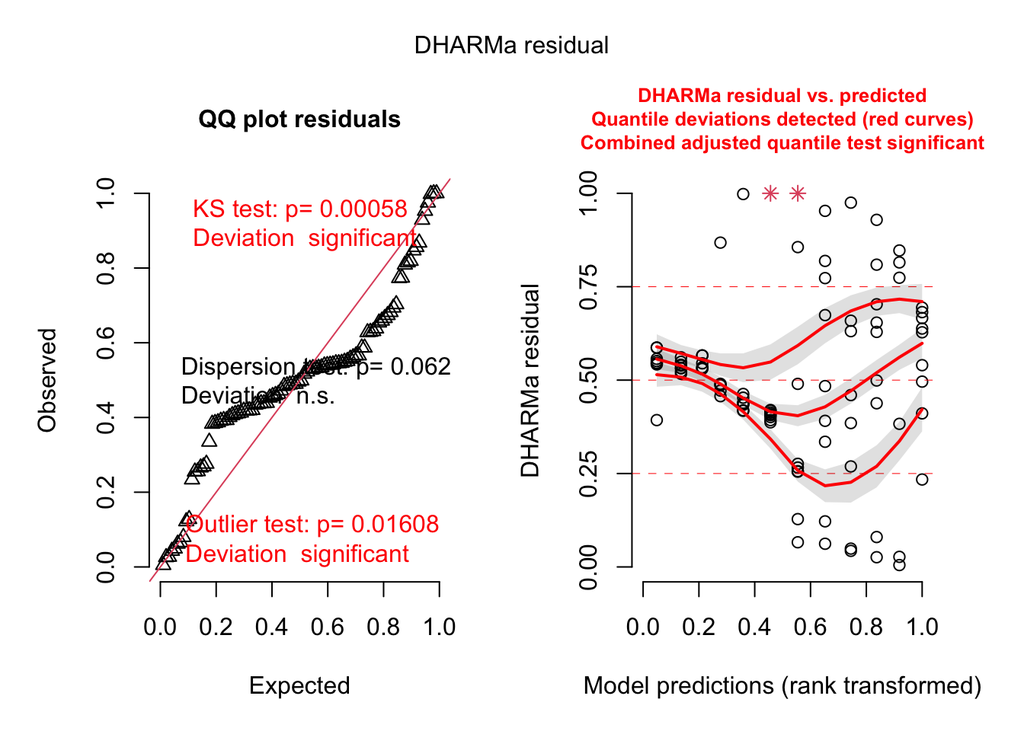

```r
ifn_sim_res <- simulateResiduals(fittedModel = ifn_glmer, n = 1000)

plot(ifn_sim_res)
```

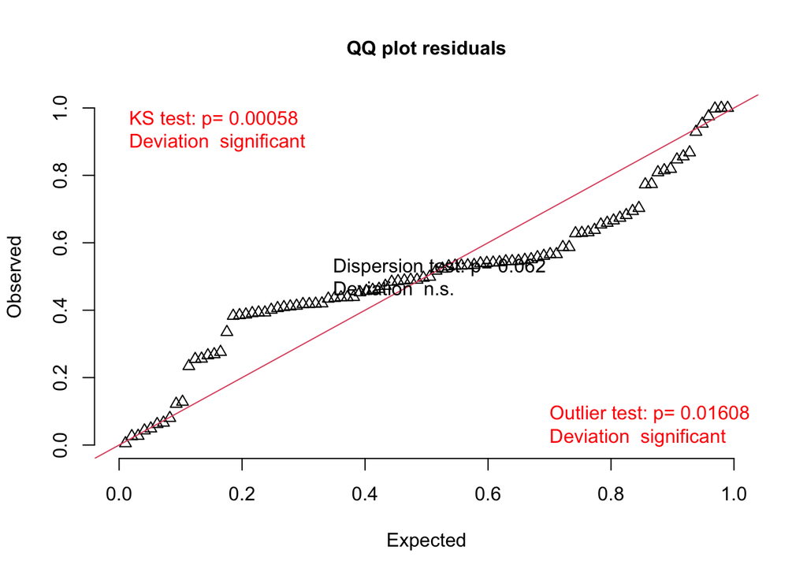

```
##
##  Asymptotic one-sample Kolmogorov-Smirnov test
##
## data:  simulationOutput$scaledResiduals
## D = 0.20592, p-value = 0.0005826
## alternative hypothesis: two-sided
```

```r
testUniformity(ifn_sim_res)
```

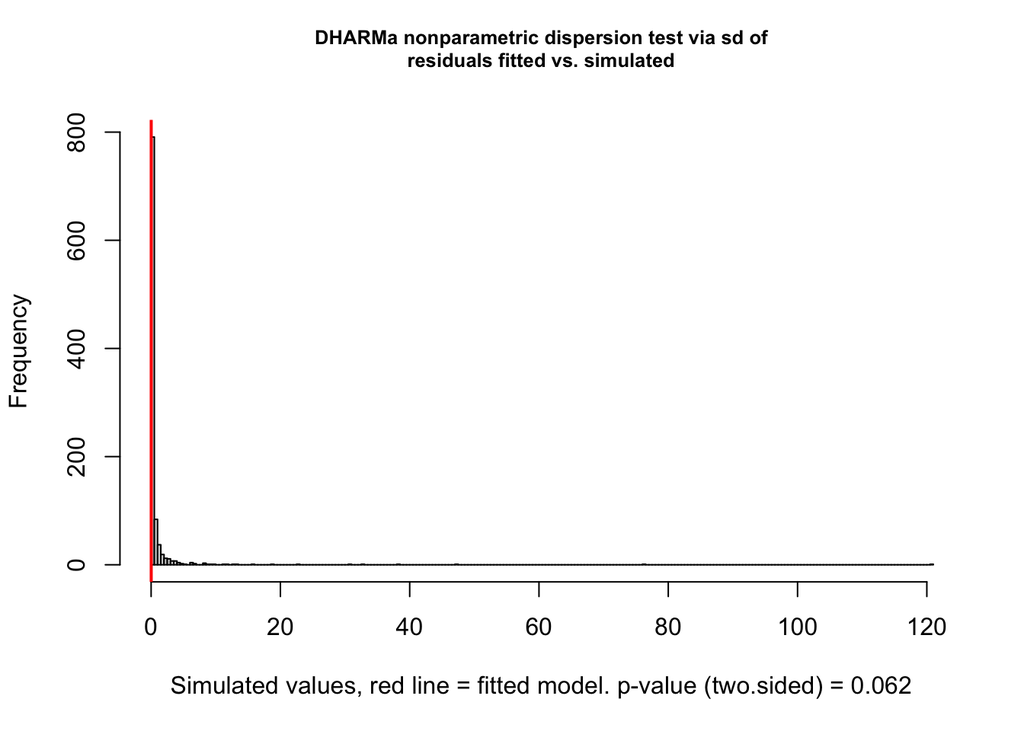

```
##
##  DHARMa nonparametric dispersion test via sd of residuals fitted vs.
##  simulated
##
## data:  simulationOutput
## dispersion = 0.015929, p-value = 0.062
## alternative hypothesis: two.sided
```

```r
testDispersion(ifn_sim_res)
```

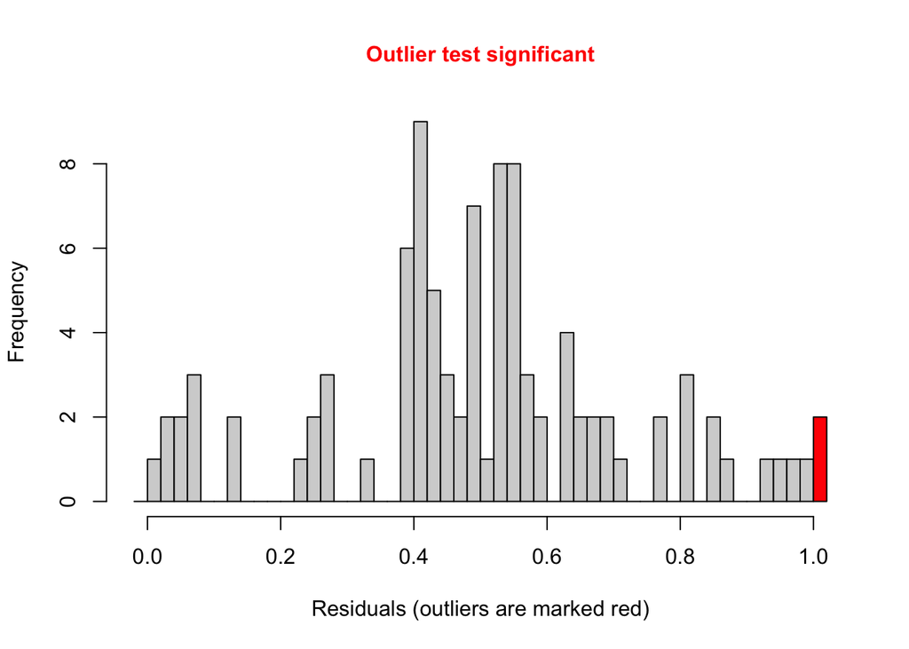

```
##
##  DHARMa outlier test based on exact binomial test with approximate
##  expectations
##
## data:  ifn_sim_res
## outliers at both margin(s) = 2, observations = 96, p-value = 0.01608
## alternative hypothesis: true probability of success is not equal to 0.001998002
## 95 percent confidence interval:
##  0.002533047 0.073236831
## sample estimates:
## frequency of outliers (expected: 0.001998001998002 )
##                                           0.02083333
```

```r
testOutliers(ifn_sim_res)
```

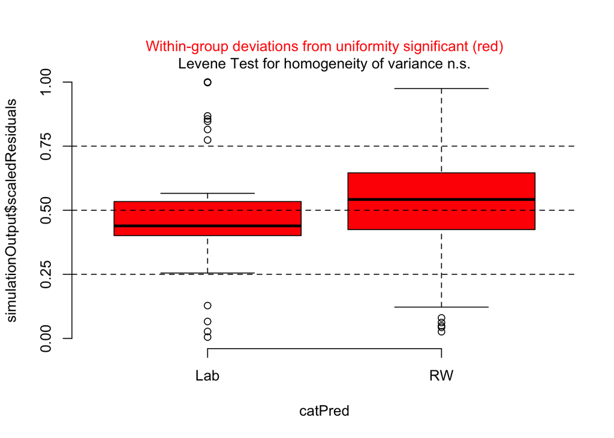

```r
plotResiduals(ifn_sim_res, form = ifn_glmer_input$lab_or_rw)
```

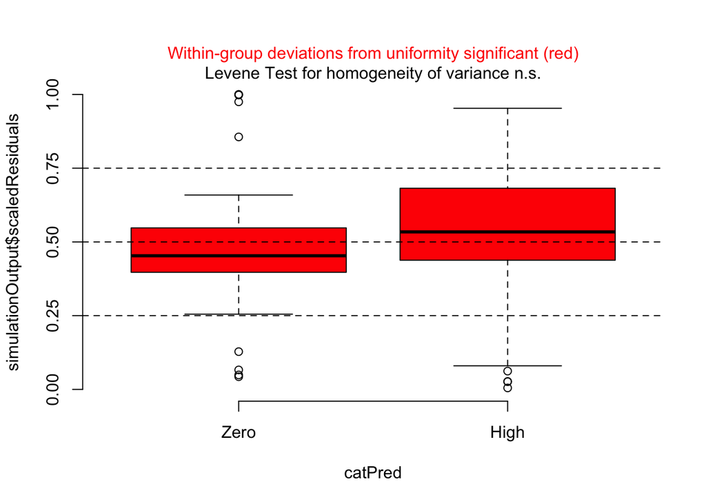

```r
plotResiduals(ifn_sim_res, form = ifn_glmer_input$t_muris_dose)
```

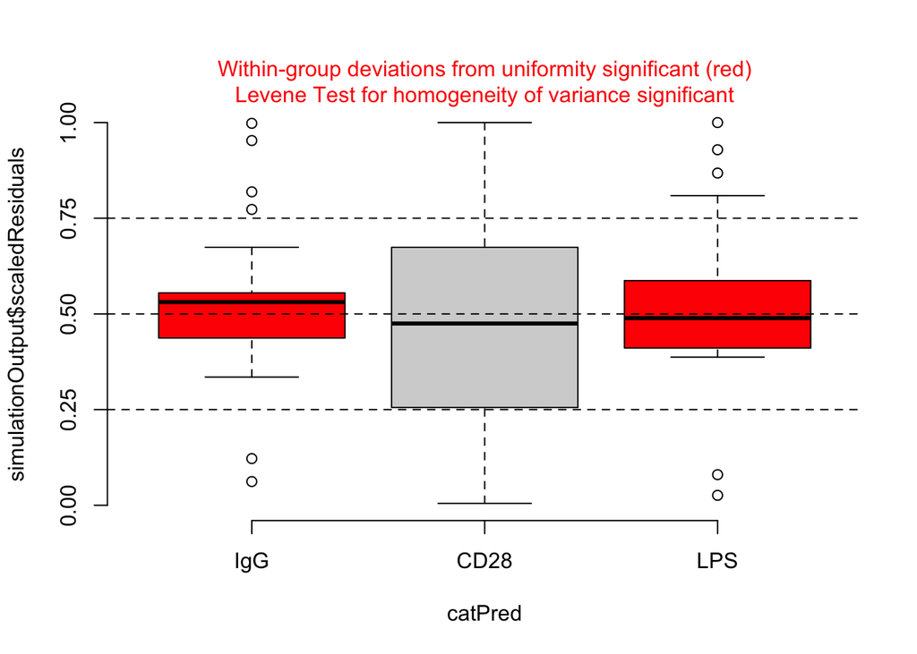

```r
plotResiduals(ifn_sim_res, form = ifn_glmer_input$treatment)
```

```r
ranef(ifn_glmer)
```

```
## $mouse_id
##      (Intercept)
## 1357  0.10187056
## 1359 -0.57711547
## 1360 -0.61121711
## 1361  0.21360103
## 1363  0.39674580
## 1364 -0.11902275
## 1366 -0.49788534
## 1367  1.29764204
## 1368  0.19653110
## 1370  0.81744506
## 1371 -0.45898926
## 1373  0.29982508
## 1374 -0.39402752
```

[output cut: 28 more lines]

```r
VarCorr(ifn_glmer)
```

```
##  Groups         Name        Std.Dev.
##  mouse_id       (Intercept) 9.0073e-01
##  experiment_day (Intercept) 3.1091e-05
##  Residual                   7.4498e-01
```

# Run emmeans for ifn

```r
emm_ifn <- emmeans(ifn_glmer,
                   specs = c("t_muris_dose","lab_or_rw"),
                   by = c("treatment"),
                   type = "response")
emm_ifn
```

```
## treatment = IgG:
##  t_muris_dose lab_or_rw response      SE  df asymp.LCL asymp.UCL
##  Zero         Lab          1.514   0.590 Inf     0.706      3.25
##  High         Lab          0.998   0.476 Inf     0.392      2.54
##  Zero         RW           0.994   0.411 Inf     0.442      2.23
##  High         RW          11.779   4.590 Inf     5.489     25.28
##
## treatment = CD28:
##  t_muris_dose lab_or_rw response      SE  df asymp.LCL asymp.UCL
##  Zero         Lab          3.089   1.200 Inf     1.439      6.63
##  High         Lab         70.935  33.900 Inf    27.840    180.74
##  Zero         RW          13.725   5.670 Inf     6.106     30.85
##  High         RW         337.694 132.000 Inf   157.351    724.73
##
## treatment = LPS:
##  t_muris_dose lab_or_rw response      SE  df asymp.LCL asymp.UCL
##  Zero         Lab          1.738   0.677 Inf     0.810      3.73
##  High         Lab          1.310   0.625 Inf     0.514      3.34
##  Zero         RW           0.903   0.373 Inf     0.402      2.03
##  High         RW          21.839   8.510 Inf    10.176     46.87
##
## Confidence level used: 0.95
## Intervals are back-transformed from the log scale
```

```r
pairs(emm_ifn)
```

```
## treatment = IgG:
##  contrast              ratio      SE  df null z.ratio p.value
##  Zero Lab / High Lab 1.51701 0.93500 Inf    1   0.676  0.9061
##  Zero Lab / Zero RW  1.52303 0.86500 Inf    1   0.741  0.8806
##  Zero Lab / High RW  0.12855 0.07080 Inf    1  -3.723  0.0011
##  High Lab / Zero RW  1.00396 0.63400 Inf    1   0.006  1.0000
##  High Lab / High RW  0.08474 0.05220 Inf    1  -4.006  0.0004
##  Zero RW / High RW   0.08440 0.04790 Inf    1  -4.353 <0.0001
##
## treatment = CD28:
##  contrast              ratio      SE  df null z.ratio p.value
##  Zero Lab / High Lab 0.04355 0.02680 Inf    1  -5.087 <0.0001
##  Zero Lab / Zero RW  0.22508 0.12800 Inf    1  -2.626  0.0429
##  Zero Lab / High RW  0.00915 0.00504 Inf    1  -8.519 <0.0001
##  High Lab / Zero RW  5.16836 3.26000 Inf    1   2.602  0.0458
##  High Lab / High RW  0.21006 0.12900 Inf    1  -2.533  0.0550
##  Zero RW / High RW   0.04064 0.02310 Inf    1  -5.639 <0.0001
##
## treatment = LPS:
##  contrast              ratio      SE  df null z.ratio p.value
##  Zero Lab / High Lab 1.32730 0.81800 Inf    1   0.460  0.9678
##  Zero Lab / Zero RW  1.92480 1.09000 Inf    1   1.153  0.6566
##  Zero Lab / High RW  0.07959 0.04390 Inf    1  -4.593 <0.0001
##  High Lab / Zero RW  1.45016 0.91500 Inf    1   0.589  0.9355
##  High Lab / High RW  0.05996 0.03690 Inf    1  -4.568 <0.0001
##  Zero RW / High RW   0.04135 0.02350 Inf    1  -5.609 <0.0001
##
## P value adjustment: tukey method for comparing a family of 4 estimates
## Tests are performed on the log scale
```

```r
kable(pairs(emm_ifn),
      digits = 3) %>%
  kable_styling(full_width = FALSE)
```

| contrast | treatment | ratio | SE | df | null | z.ratio | p.value |
| --- | --- | --- | --- | --- | --- | --- | --- |
| Zero Lab / High Lab | IgG | 1.517 | 0.935 | Inf | 1 | 0.676 | 0.906 |
| Zero Lab / Zero RW | IgG | 1.523 | 0.865 | Inf | 1 | 0.741 | 0.881 |
| Zero Lab / High RW | IgG | 0.129 | 0.071 | Inf | 1 | -3.723 | 0.001 |
| High Lab / Zero RW | IgG | 1.004 | 0.634 | Inf | 1 | 0.006 | 1.000 |
| High Lab / High RW | IgG | 0.085 | 0.052 | Inf | 1 | -4.006 | 0.000 |
| Zero RW / High RW | IgG | 0.084 | 0.048 | Inf | 1 | -4.353 | 0.000 |
| Zero Lab / High Lab | CD28 | 0.044 | 0.027 | Inf | 1 | -5.087 | 0.000 |
| Zero Lab / Zero RW | CD28 | 0.225 | 0.128 | Inf | 1 | -2.626 | 0.043 |
| Zero Lab / High RW | CD28 | 0.009 | 0.005 | Inf | 1 | -8.519 | 0.000 |
| High Lab / Zero RW | CD28 | 5.168 | 3.263 | Inf | 1 | 2.602 | 0.046 |
| High Lab / High RW | CD28 | 0.210 | 0.129 | Inf | 1 | -2.533 | 0.055 |
| Zero RW / High RW | CD28 | 0.041 | 0.023 | Inf | 1 | -5.639 | 0.000 |
| Zero Lab / High Lab | LPS | 1.327 | 0.818 | Inf | 1 | 0.460 | 0.968 |
| Zero Lab / Zero RW | LPS | 1.925 | 1.093 | Inf | 1 | 1.153 | 0.657 |
| Zero Lab / High RW | LPS | 0.080 | 0.044 | Inf | 1 | -4.593 | 0.000 |
| High Lab / Zero RW | LPS | 1.450 | 0.915 | Inf | 1 | 0.589 | 0.936 |
| High Lab / High RW | LPS | 0.060 | 0.037 | Inf | 1 | -4.568 | 0.000 |
| Zero RW / High RW | LPS | 0.041 | 0.023 | Inf | 1 | -5.609 | 0.000 |

```r
emm_ifn_trt <- emmeans(ifn_glmer,
                       specs = "treatment",
                       by = c("t_muris_dose", "lab_or_rw"),
                       type = "response")

pairs(emm_ifn_trt)
```

```
## t_muris_dose = Zero, lab_or_rw = Lab:
##  contrast     ratio       SE  df null z.ratio p.value
##  IgG / CD28  0.4902  0.17200 Inf    1  -2.030  0.1050
##  IgG / LPS   0.8712  0.30600 Inf    1  -0.393  0.9185
##  CD28 / LPS  1.7773  0.62400 Inf    1   1.638  0.2298
##
## t_muris_dose = High, lab_or_rw = Lab:
##  contrast     ratio       SE  df null z.ratio p.value
##  IgG / CD28  0.0141  0.00605 Inf    1  -9.913 <0.0001
##  IgG / LPS   0.7622  0.32800 Inf    1  -0.631  0.8029
##  CD28 / LPS 54.1691 23.30000 Inf    1   9.282 <0.0001
##
## t_muris_dose = Zero, lab_or_rw = RW:
##  contrast     ratio       SE  df null z.ratio p.value
##  IgG / CD28  0.0724  0.02700 Inf    1  -7.047 <0.0001
##  IgG / LPS   1.1010  0.41000 Inf    1   0.258  0.9639
##  CD28 / LPS 15.1990  5.66000 Inf    1   7.306 <0.0001
##
## t_muris_dose = High, lab_or_rw = RW:
##  contrast     ratio       SE  df null z.ratio p.value
##  IgG / CD28  0.0349  0.01220 Inf    1  -9.556 <0.0001
##  IgG / LPS   0.5394  0.18900 Inf    1  -1.758  0.1839
##  CD28 / LPS 15.4628  5.43000 Inf    1   7.798 <0.0001
##
## P value adjustment: tukey method for comparing a family of 3 estimates
## Tests are performed on the log scale
```

```r
kable(pairs(emm_ifn_trt),
      digits = 3) %>%
  kable_styling(full_width = FALSE)
```

| contrast | t_muris_dose | lab_or_rw | ratio | SE | df | null | z.ratio | p.value |
| --- | --- | --- | --- | --- | --- | --- | --- | --- |
| IgG / CD28 | Zero | Lab | 0.490 | 0.172 | Inf | 1 | -2.030 | 0.105 |
| IgG / LPS | Zero | Lab | 0.871 | 0.306 | Inf | 1 | -0.393 | 0.919 |
| CD28 / LPS | Zero | Lab | 1.777 | 0.624 | Inf | 1 | 1.638 | 0.230 |
| IgG / CD28 | High | Lab | 0.014 | 0.006 | Inf | 1 | -9.913 | 0.000 |
| IgG / LPS | High | Lab | 0.762 | 0.328 | Inf | 1 | -0.631 | 0.803 |
| CD28 / LPS | High | Lab | 54.169 | 23.299 | Inf | 1 | 9.282 | 0.000 |
| IgG / CD28 | Zero | RW | 0.072 | 0.027 | Inf | 1 | -7.047 | 0.000 |
| IgG / LPS | Zero | RW | 1.101 | 0.410 | Inf | 1 | 0.258 | 0.964 |
| CD28 / LPS | Zero | RW | 15.199 | 5.661 | Inf | 1 | 7.306 | 0.000 |
| IgG / CD28 | High | RW | 0.035 | 0.012 | Inf | 1 | -9.556 | 0.000 |
| IgG / LPS | High | RW | 0.539 | 0.189 | Inf | 1 | -1.758 | 0.184 |
| CD28 / LPS | High | RW | 15.463 | 5.430 | Inf | 1 | 7.798 | 0.000 |

# Doing the same thing here

# The lowest detection level is 3.7 for TNF so halving that.

```r
tnf_input <- tnf_input %>%
  mutate(
    t_muris_dose = relevel(factor(t_muris_dose),
                           ref = "Zero"),
    treatment = relevel(factor(treatment),
                        ref = "IgG"),
    lab_or_rw = relevel(factor(lab_or_rw),
                        ref = "Lab")
  )

tnf_glmer_input <- tnf_input %>%
  mutate(mean_concentration = ifelse(mean_concentration == 0,
                                     3.7 / 2,
                                     mean_concentration))

# we want to set the zero dose, IgG and lab groups to be the basis of all our comparisons.

tnf_glmer <- glmer(mean_concentration ~ lab_or_rw *
                     t_muris_dose *
                     treatment +
                     (1 | mouse_id) +
                     (1 | experiment_day),
                  family = Gamma(link = "log"),
                  control = glmerControl(optimizer = "bobyqa",
                                         optCtrl = list(maxfun = 2e5)),
                 data = tnf_glmer_input)
```

```
## boundary (singular) fit: see help('isSingular')
```

```r
tab_model(tnf_glmer, show.stat = TRUE)
```

```
## boundary (singular) fit: see help('isSingular')
```

|  | mean concentration |  |  |  |
| --- | --- | --- | --- | --- |
| Predictors | Estimates | CI | Statistic | p |
| (Intercept) | 23.05 | 16.16 – 32.87 | 17.58 | **<0.001** |
| lab or rw [RW] | 0.95 | 0.56 – 1.59 | -0.21 | 0.836 |
| t muris dose [High] | 1.84 | 1.05 – 3.23 | 2.17 | **0.033** |
| treatment [CD28] | 1.23 | 0.82 – 1.84 | 1.01 | 0.314 |
| treatment [LPS] | 2.19 | 1.46 – 3.28 | 3.87 | **<0.001** |
| lab or rw [RW] × t muris dose [High] | 1.83 | 0.85 – 3.92 | 1.57 | 0.121 |
| lab or rw [RW] × treatment [CD28] | 1.57 | 0.87 – 2.83 | 1.53 | 0.131 |
| lab or rw [RW] × treatment [LPS] | 1.14 | 0.63 – 2.05 | 0.44 | 0.662 |
| t muris dose [High] × treatment [CD28] | 1.19 | 0.63 – 2.26 | 0.55 | 0.584 |
| t muris dose [High] × treatment [LPS] | 0.64 | 0.34 – 1.21 | -1.39 | 0.169 |
| (lab or rw [RW] × t muris dose [High]) × treatment [CD28] | 0.72 | 0.30 – 1.73 | -0.74 | 0.463 |
| (lab or rw [RW] × t muris dose [High]) × treatment [LPS] | 1.15 | 0.48 – 2.75 | 0.33 | 0.746 |
| Random Effects |  |  |  |  |
| σ<sup>2</sup> | 0.17 |  |  |  |
| τ<sub>00</sub> <sub>mouse_id</sub> | 0.10 |  |  |  |
| τ<sub>00</sub> <sub>experiment_day</sub> | 0.00 |  |  |  |
| N <sub>mouse_id</sub> | 32 |  |  |  |
| N <sub>experiment_day</sub> | 4 |  |  |  |
| Observations | 96 |  |  |  |
| Marginal R<sup>2</sup> / Conditional R<sup>2</sup> | 0.666 / NA |  |  |  |

```r
# statistic is t-value btw

summary(tnf_glmer)
```

```
## Generalized linear mixed model fit by maximum likelihood (Laplace
##   Approximation) [glmerMod]
##  Family: Gamma  ( log )
## Formula: mean_concentration ~ lab_or_rw * t_muris_dose * treatment + (1 |
##     mouse_id) + (1 | experiment_day)
##    Data: tnf_glmer_input
## Control: glmerControl(optimizer = "bobyqa", optCtrl = list(maxfun = 2e+05))
##
##       AIC       BIC    logLik -2*log(L)  df.resid
##     952.7     991.2    -461.3     922.7        81
##
## Scaled residuals:
##      Min       1Q   Median       3Q      Max
## -2.21568 -0.30914  0.07227  0.53153  1.82232
##
## Random effects:
##  Groups         Name        Variance Std.Dev.
##  mouse_id       (Intercept) 0.1011   0.3180
##  experiment_day (Intercept) 0.0000   0.0000
##  Residual                   0.1854   0.4306
## Number of obs: 96, groups:  mouse_id, 32; experiment_day, 4
##
## Fixed effects:
##                                            Estimate Std. Error t value Pr(>|z|)
## (Intercept)                                 3.13748    0.17843  17.584  < 2e-16
## lab_or_rwRW                                -0.05402    0.26011  -0.208 0.835464
## t_muris_doseHigh                            0.61238    0.28213   2.171 0.029963
## treatmentCD28                               0.20566    0.20299   1.013 0.310977
## treatmentLPS                                0.78482    0.20299   3.866 0.000111
## lab_or_rwRW:t_muris_doseHigh                0.60202    0.38373   1.569 0.116681
## lab_or_rwRW:treatmentCD28                   0.45128    0.29591   1.525 0.127241
## lab_or_rwRW:treatmentLPS                    0.12976    0.29591   0.439 0.661011
## t_muris_doseHigh:treatmentCD28              0.17624    0.32095   0.549 0.582918
## t_muris_doseHigh:treatmentLPS              -0.44592    0.32095  -1.389 0.164726
## lab_or_rwRW:t_muris_doseHigh:treatmentCD28 -0.32167    0.43655  -0.737 0.461204
## lab_or_rwRW:t_muris_doseHigh:treatmentLPS   0.14191    0.43655   0.325 0.745120
##
## (Intercept)                                ***
## lab_or_rwRW
## t_muris_doseHigh                           *
```

[output cut: 24 more lines]

```
## l__RW:__H:L -0.264  0.386  0.418  0.232  0.465 -0.569     -0.339  -0.678
##             t__H:C t__H:L l__RW:__H:C
## lab_or_rwRW
## t_mrs_dsHgh
## tretmntCD28
## treatmntLPS
## lb_r_RW:__H
## lb__RW:CD28
## lb_r_RW:LPS
## t_mr_H:CD28
## t_mrs_H:LPS  0.500
## l__RW:__H:C -0.735 -0.368
## l__RW:__H:L -0.368 -0.735  0.500
## optimizer (bobyqa) convergence code: 0 (OK)
## boundary (singular) fit: see help('isSingular')
```

# Diagnostics for tnf

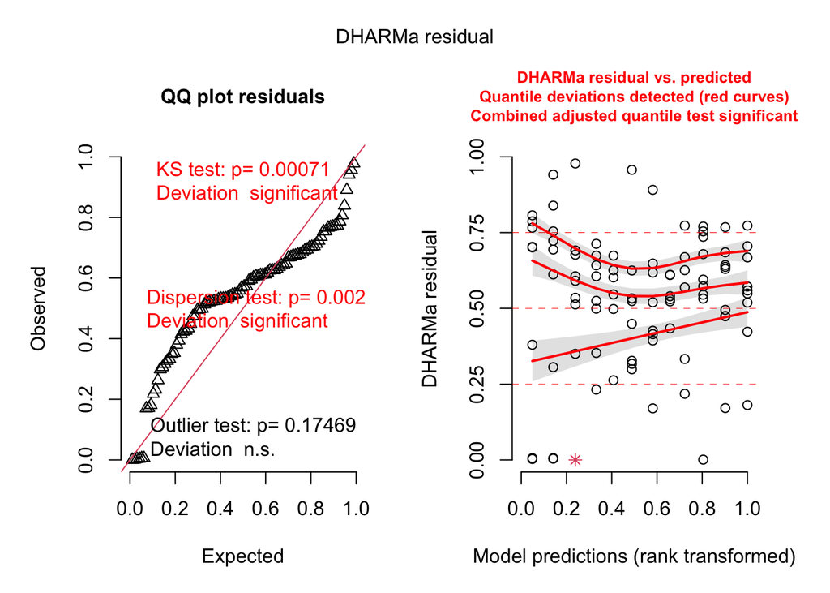

```r
tnf_sim_res <- simulateResiduals(fittedModel = tnf_glmer, n = 1000)

plot(tnf_sim_res)
```

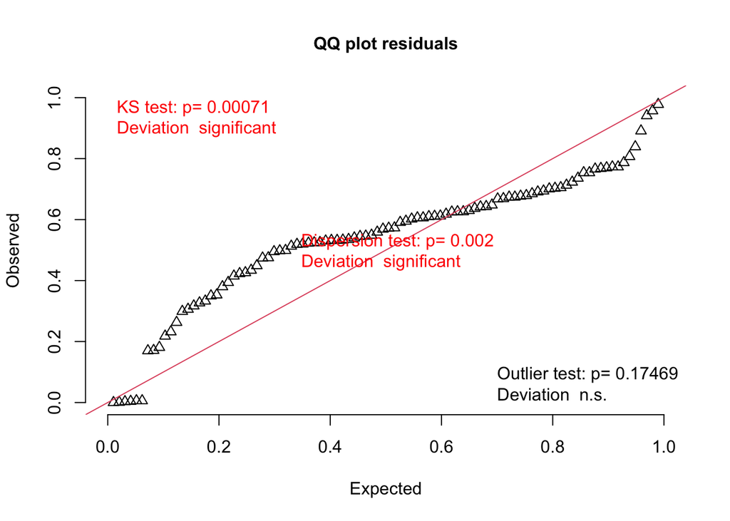

```
##
##  Asymptotic one-sample Kolmogorov-Smirnov test
##
## data:  simulationOutput$scaledResiduals
## D = 0.20333, p-value = 0.0007137
## alternative hypothesis: two-sided
```

```r
testUniformity(tnf_sim_res)
```

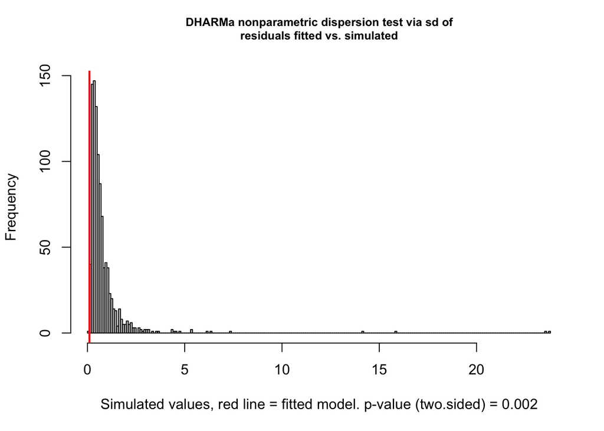

```
##
##  DHARMa nonparametric dispersion test via sd of residuals fitted vs.
##  simulated
##
## data:  simulationOutput
## dispersion = 0.12229, p-value = 0.002
## alternative hypothesis: two.sided
```

```r
testDispersion(tnf_sim_res)
```

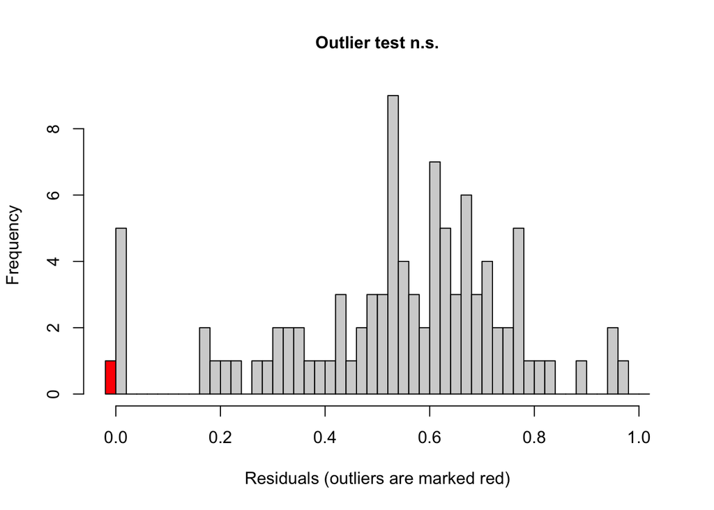

```
##
##  DHARMa outlier test based on exact binomial test with approximate
##  expectations
##
## data:  tnf_sim_res
## outliers at both margin(s) = 1, observations = 96, p-value = 0.1747
## alternative hypothesis: true probability of success is not equal to 0.001998002
## 95 percent confidence interval:
##  0.0002636924 0.0566747070
## sample estimates:
## frequency of outliers (expected: 0.001998001998002 )
##                                           0.01041667
```

```r
testOutliers(tnf_sim_res)
```

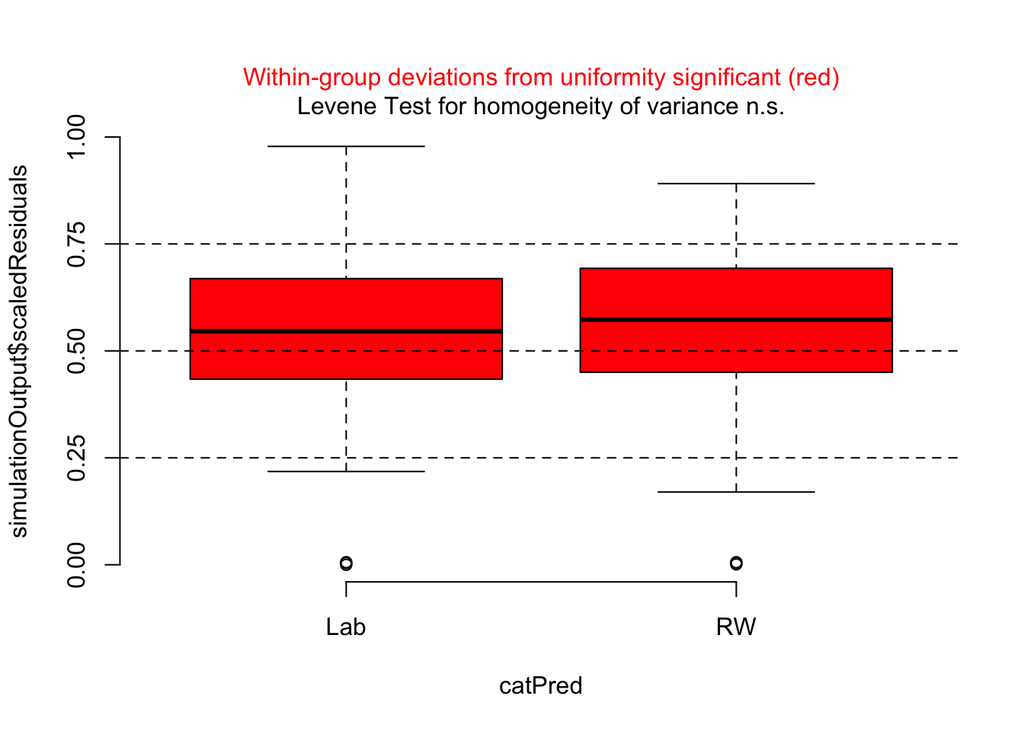

```r
plotResiduals(tnf_sim_res, form = tnf_glmer_input$lab_or_rw)
```

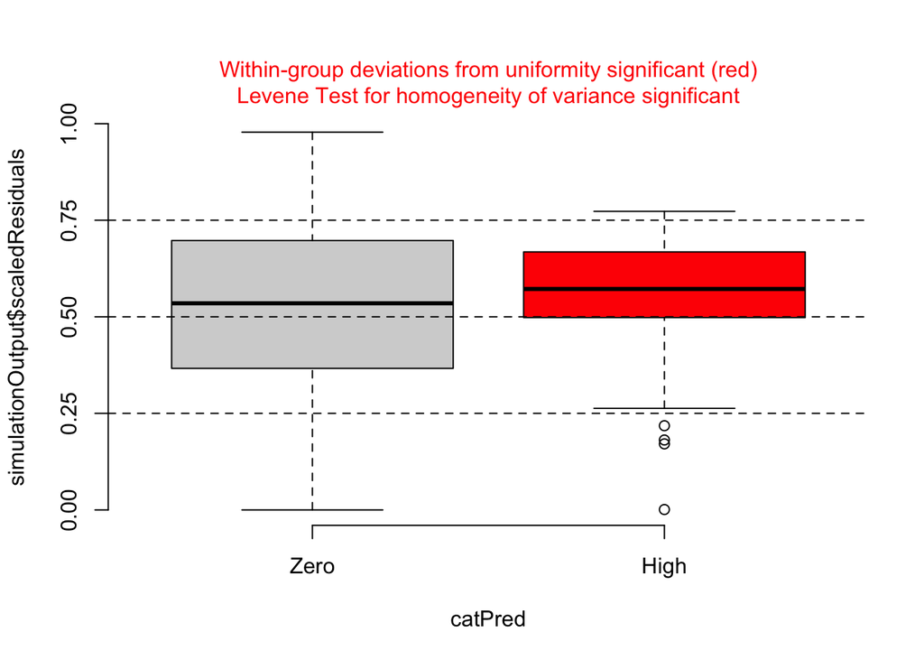

```r
plotResiduals(tnf_sim_res, form = tnf_glmer_input$t_muris_dose)
```

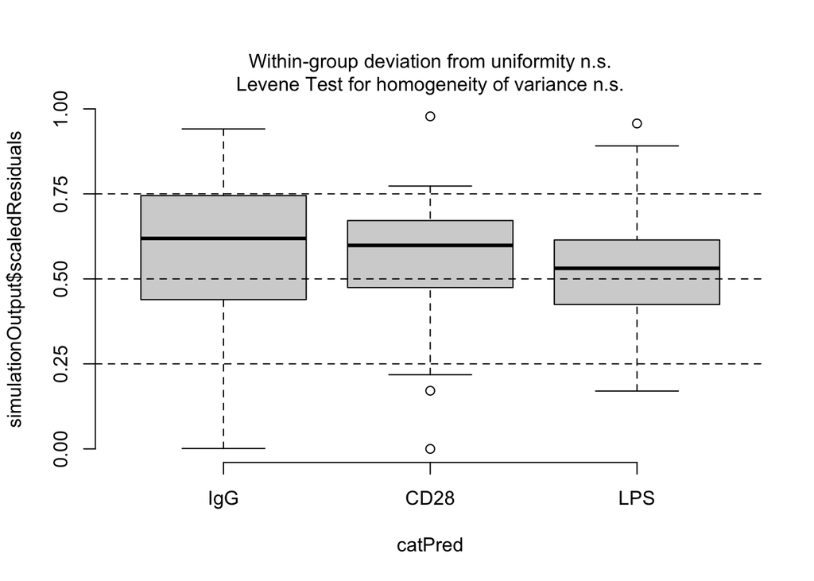

```r
plotResiduals(tnf_sim_res, form = tnf_glmer_input$treatment)
```

```r
ranef(tnf_glmer)
```

```
## $mouse_id
##       (Intercept)
## 1357  0.042478440
## 1359  0.203210997
## 1360  0.035079580
## 1361  0.194792017
## 1363  0.154857138
## 1364  0.160186038
## 1366 -0.171686110
## 1367  0.133837470
## 1368  0.061095941
## 1370  0.145734526
## 1371  0.191508907
## 1373  0.044236847
## 1374  0.045002963
```

[output cut: 28 more lines]

```r
VarCorr(tnf_glmer)
```

```
##  Groups         Name        Std.Dev.
##  mouse_id       (Intercept) 0.31800
##  experiment_day (Intercept) 0.00000
##  Residual                   0.43061
```

# Run emmeans for tnf

```r
emm_tnf <- emmeans(tnf_glmer,
                   specs = c("t_muris_dose", "lab_or_rw"),
                   by = c("treatment"),
                   type = "response")

emm_tnf
```

```
## treatment = IgG:
##  t_muris_dose lab_or_rw response    SE  df asymp.LCL asymp.UCL
##  Zero         Lab           23.0  4.11 Inf      16.2      32.7
##  High         Lab           42.5  9.29 Inf      27.7      65.2
##  Zero         RW            21.8  4.13 Inf      15.1      31.6
##  High         RW            73.5 13.10 Inf      51.8     104.3
##
## treatment = CD28:
##  t_muris_dose lab_or_rw response    SE  df asymp.LCL asymp.UCL
##  Zero         Lab           28.3  5.05 Inf      20.0      40.2
##  High         Lab           62.3 13.60 Inf      40.6      95.6
##  Zero         RW            42.1  7.97 Inf      29.1      61.0
##  High         RW           122.7 21.90 Inf      86.5     174.0
##
## treatment = LPS:
##  t_muris_dose lab_or_rw response    SE  df asymp.LCL asymp.UCL
##  Zero         Lab           50.5  9.01 Inf      35.6      71.7
##  High         Lab           59.7 13.00 Inf      38.9      91.6
##  Zero         RW            54.5 10.30 Inf      37.6      79.0
##  High         RW           135.4 24.20 Inf      95.5     192.1
##
## Confidence level used: 0.95
## Intervals are back-transformed from the log scale
```

```r
pairs(emm_tnf)
```

```
## treatment = IgG:
##  contrast            ratio     SE  df null z.ratio p.value
##  Zero Lab / High Lab 0.542 0.1530 Inf    1  -2.171  0.1315
##  Zero Lab / Zero RW  1.056 0.2750 Inf    1   0.208  0.9968
##  Zero Lab / High RW  0.313 0.0791 Inf    1  -4.598 <0.0001
##  High Lab / Zero RW  1.947 0.5630 Inf    1   2.305  0.0968
##  High Lab / High RW  0.578 0.1630 Inf    1  -1.942  0.2104
##  Zero RW / High RW   0.297 0.0772 Inf    1  -4.669 <0.0001
##
## treatment = CD28:
##  contrast            ratio     SE  df null z.ratio p.value
##  Zero Lab / High Lab 0.454 0.1280 Inf    1  -2.795  0.0266
##  Zero Lab / Zero RW  0.672 0.1750 Inf    1  -1.527  0.4211
##  Zero Lab / High RW  0.231 0.0582 Inf    1  -5.810 <0.0001
##  High Lab / Zero RW  1.479 0.4280 Inf    1   1.354  0.5286
##  High Lab / High RW  0.508 0.1430 Inf    1  -2.402  0.0767
##  Zero RW / High RW   0.343 0.0893 Inf    1  -4.110  0.0002
##
## treatment = LPS:
##  contrast            ratio     SE  df null z.ratio p.value
##  Zero Lab / High Lab 0.847 0.2390 Inf    1  -0.590  0.9351
##  Zero Lab / Zero RW  0.927 0.2410 Inf    1  -0.291  0.9914
##  Zero Lab / High RW  0.373 0.0941 Inf    1  -3.908  0.0005
##  High Lab / Zero RW  1.095 0.3170 Inf    1   0.314  0.9893
##  High Lab / High RW  0.441 0.1240 Inf    1  -2.905  0.0192
##  Zero RW / High RW   0.402 0.1050 Inf    1  -3.500  0.0026
##
## P value adjustment: tukey method for comparing a family of 4 estimates
## Tests are performed on the log scale
```

```r
kable(pairs(emm_tnf),
      digits = 3) %>%
  kable_styling(full_width = FALSE)
```

| contrast | treatment | ratio | SE | df | null | z.ratio | p.value |
| --- | --- | --- | --- | --- | --- | --- | --- |
| Zero Lab / High Lab | IgG | 0.542 | 0.153 | Inf | 1 | -2.171 | 0.131 |
| Zero Lab / Zero RW | IgG | 1.056 | 0.275 | Inf | 1 | 0.208 | 0.997 |
| Zero Lab / High RW | IgG | 0.313 | 0.079 | Inf | 1 | -4.598 | 0.000 |
| High Lab / Zero RW | IgG | 1.947 | 0.563 | Inf | 1 | 2.305 | 0.097 |
| High Lab / High RW | IgG | 0.578 | 0.163 | Inf | 1 | -1.942 | 0.210 |
| Zero RW / High RW | IgG | 0.297 | 0.077 | Inf | 1 | -4.669 | 0.000 |
| Zero Lab / High Lab | CD28 | 0.454 | 0.128 | Inf | 1 | -2.795 | 0.027 |
| Zero Lab / Zero RW | CD28 | 0.672 | 0.175 | Inf | 1 | -1.527 | 0.421 |
| Zero Lab / High RW | CD28 | 0.231 | 0.058 | Inf | 1 | -5.810 | 0.000 |
| High Lab / Zero RW | CD28 | 1.479 | 0.428 | Inf | 1 | 1.354 | 0.529 |
| High Lab / High RW | CD28 | 0.508 | 0.143 | Inf | 1 | -2.402 | 0.077 |
| Zero RW / High RW | CD28 | 0.343 | 0.089 | Inf | 1 | -4.110 | 0.000 |
| Zero Lab / High Lab | LPS | 0.847 | 0.239 | Inf | 1 | -0.590 | 0.935 |
| Zero Lab / Zero RW | LPS | 0.927 | 0.241 | Inf | 1 | -0.291 | 0.991 |
| Zero Lab / High RW | LPS | 0.373 | 0.094 | Inf | 1 | -3.908 | 0.001 |
| High Lab / Zero RW | LPS | 1.095 | 0.317 | Inf | 1 | 0.314 | 0.989 |
| High Lab / High RW | LPS | 0.441 | 0.124 | Inf | 1 | -2.905 | 0.019 |
| Zero RW / High RW | LPS | 0.402 | 0.105 | Inf | 1 | -3.500 | 0.003 |

```r
emm_tnf_trt <- emmeans(tnf_glmer,
                       specs = "treatment",
                       by = c("t_muris_dose", "lab_or_rw"),
                       type = "response")

pairs(emm_tnf_trt)
```

```
## t_muris_dose = Zero, lab_or_rw = Lab:
##  contrast   ratio     SE  df null z.ratio p.value
##  IgG / CD28 0.814 0.1650 Inf    1  -1.013  0.5685
##  IgG / LPS  0.456 0.0926 Inf    1  -3.866  0.0003
##  CD28 / LPS 0.560 0.1140 Inf    1  -2.853  0.0120
##
## t_muris_dose = High, lab_or_rw = Lab:
##  contrast   ratio     SE  df null z.ratio p.value
##  IgG / CD28 0.683 0.1700 Inf    1  -1.536  0.2740
##  IgG / LPS  0.713 0.1770 Inf    1  -1.363  0.3604
##  CD28 / LPS 1.044 0.2600 Inf    1   0.173  0.9836
##
## t_muris_dose = Zero, lab_or_rw = RW:
##  contrast   ratio     SE  df null z.ratio p.value
##  IgG / CD28 0.518 0.1120 Inf    1  -3.051  0.0064
##  IgG / LPS  0.401 0.0863 Inf    1  -4.248 <0.0001
##  CD28 / LPS 0.773 0.1660 Inf    1  -1.197  0.4552
##
## t_muris_dose = High, lab_or_rw = RW:
##  contrast   ratio     SE  df null z.ratio p.value
##  IgG / CD28 0.600 0.1220 Inf    1  -2.520  0.0315
##  IgG / LPS  0.543 0.1100 Inf    1  -3.008  0.0074
##  CD28 / LPS 0.906 0.1840 Inf    1  -0.488  0.8770
##
## P value adjustment: tukey method for comparing a family of 3 estimates
## Tests are performed on the log scale
```

```r
kable(pairs(emm_tnf_trt),
      digits = 3) %>%
  kable_styling(full_width = FALSE)
```

| contrast | t_muris_dose | lab_or_rw | ratio | SE | df | null | z.ratio | p.value |
| --- | --- | --- | --- | --- | --- | --- | --- | --- |
| IgG / CD28 | Zero | Lab | 0.814 | 0.165 | Inf | 1 | -1.013 | 0.569 |
| IgG / LPS | Zero | Lab | 0.456 | 0.093 | Inf | 1 | -3.866 | 0.000 |
| CD28 / LPS | Zero | Lab | 0.560 | 0.114 | Inf | 1 | -2.853 | 0.012 |
| IgG / CD28 | High | Lab | 0.683 | 0.170 | Inf | 1 | -1.536 | 0.274 |
| IgG / LPS | High | Lab | 0.713 | 0.177 | Inf | 1 | -1.363 | 0.360 |
| CD28 / LPS | High | Lab | 1.044 | 0.260 | Inf | 1 | 0.173 | 0.984 |
| IgG / CD28 | Zero | RW | 0.518 | 0.112 | Inf | 1 | -3.051 | 0.006 |
| IgG / LPS | Zero | RW | 0.401 | 0.086 | Inf | 1 | -4.248 | 0.000 |
| CD28 / LPS | Zero | RW | 0.773 | 0.166 | Inf | 1 | -1.197 | 0.455 |
| IgG / CD28 | High | RW | 0.600 | 0.122 | Inf | 1 | -2.520 | 0.032 |
| IgG / LPS | High | RW | 0.543 | 0.110 | Inf | 1 | -3.008 | 0.007 |
| CD28 / LPS | High | RW | 0.906 | 0.184 | Inf | 1 | -0.488 | 0.877 |

# EMM data frames

```r
emm_ifn_df <- as.data.frame(emm_ifn) %>%
  mutate(treatment = factor(treatment,
                            levels = c("IgG",
                                       "LPS",
                                       "CD28")),
         t_muris_dose = factor(t_muris_dose,
                               levels = c("Zero",
                                          "High")),
         lab_or_rw = factor(lab_or_rw,
                            levels = c("Lab",
                                       "RW")))

emm_tnf_df <- as.data.frame(emm_tnf) %>%
  mutate(treatment = factor(treatment,
                            levels = c("IgG",
                                       "LPS",
                                       "CD28")),
         t_muris_dose = factor(t_muris_dose,
                               levels = c("Zero",
                                          "High")),
         lab_or_rw = factor(lab_or_rw,
                            levels = c("Lab",
                                       "RW")))
```

# Plotting IFN faceted by treatment

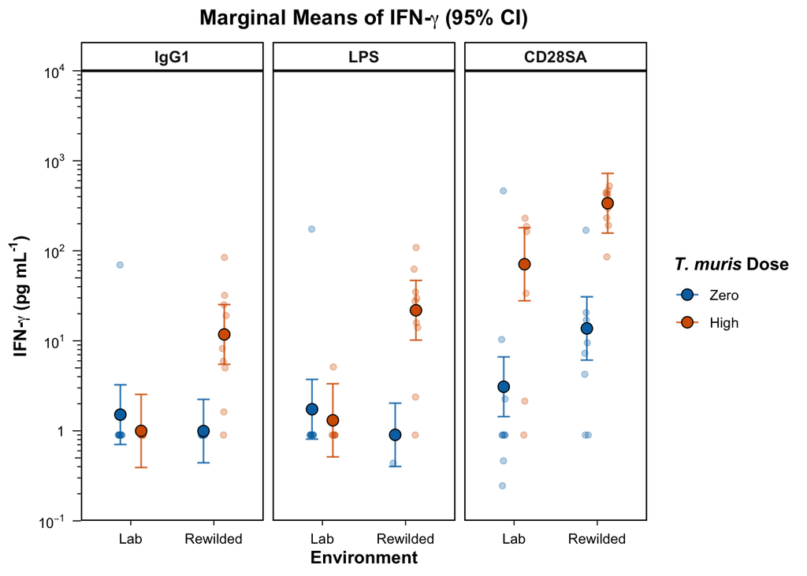

```r
# We're plotting the LOD/2 values as the data points as well.
# That is what those clustered points are. Those were zeros.

emm_ifn_plot <- ggplot(emm_ifn_df) +
  geom_point(data = ifn_glmer_input %>%
               mutate(treatment = factor(treatment,
                                         levels = c("IgG",
                                                    "LPS",
                                                    "CD28")),
                      lab_or_rw = factor(lab_or_rw,
                                         levels = c("Lab",
                                                    "RW")),
                      t_muris_dose = factor(t_muris_dose,
                                            levels = c("Zero",
                                                       "High"))),
             aes(x = lab_or_rw,
                 y = mean_concentration,
                 color = t_muris_dose),
             position = position_jitterdodge(jitter.width = 0.1,
                                             dodge.width = 0.5),
             alpha = 0.3,
             size = 1.5) +
  geom_errorbar(aes(x = lab_or_rw,
                    ymin = asymp.LCL,
                    ymax = asymp.UCL,
                    color = t_muris_dose),
                width = 0.3,
                position = position_dodge(width = 0.5),
                alpha = 0.8) +
  geom_point(aes(x = lab_or_rw,
                 y = response,
                 fill = t_muris_dose),
             position = position_dodge(width = 0.5),
             alpha = 1,
             size = 3,
             shape = 21,
             color = "black") +
  scale_fill_manual(values = c("Zero" = color_dark_blue,
                               "High" = color_orange),
                    name = expression(bolditalic("T. muris") ~ bold("Dose"))) +
  scale_color_manual(values = c("Zero" = color_dark_blue,
                                "High" = color_orange),
                     name = expression(bolditalic("T. muris") ~ bold("Dose"))) +
  scale_y_continuous(name = expression(bold("IFN-" * gamma ~
                                              "(pg mL"^"-1" * ")")),
                     expand = expansion(mult = 0),
                     trans = "log10",
                     breaks = 10^seq(-1, 4),
                     labels = expression(10^-1, 1, 10^1,
                                         10^2, 10^3, 10^4),
                     limits = c(0.1, 10000),
                     guide = guide_axis_logticks(long = 1.8,
                                                mid = 1.3,
                                                short = 0.8,
                                                expanded = FALSE)) +
  scale_x_discrete(name = expression(bold("Environment")),
                   labels = c("Lab" = "Lab",
                              "RW"  = "Rewilded")) +
  facet_wrap(~ treatment,
             labeller = as_labeller(c("CD28" = "CD28SA",
                                      "LPS" = "LPS",
                                      "IgG" = "IgG1"))) +
  theme_minimal() +
  theme(strip.background = element_rect(fill = "white",
                                        color = "black",
                                        linewidth = 0.8),
        strip.text = element_text(size = 10,
                                  face = "bold"),
        panel.border = element_rect(color = "black",
                                    fill = NA,
                                    linewidth = 0.8),
        panel.grid = element_blank(),
        plot.title = element_text(hjust = 0.5, face = "bold"),
        axis.title.x = element_text(face = "bold"),
        axis.title.y = element_text(face = "bold"),
        axis.text = element_text(color = "black"),
        axis.ticks = element_line(color = "black",
                                  linewidth = 0.3),
        axis.ticks.length = unit(0.1, "cm")) +
  ggtitle(expression(bold("Marginal Means of IFN-" * gamma ~ "(95% CI)")))

emm_ifn_plot
```

```r
plot_saver("emm_ifn_plot.png",
           emm_ifn_plot)
svg_saver("emm_ifn_plot.svg",
          emm_ifn_plot)
```

# Plotting IFN faceted by dose

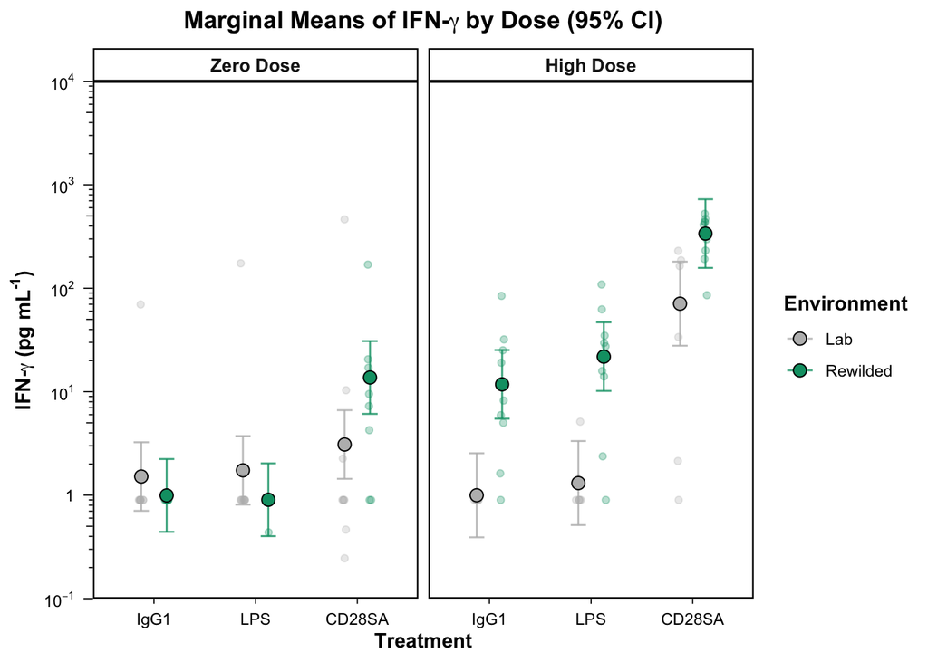

```r
emm_ifn_dose_plot <- ggplot(emm_ifn_df) +
  geom_point(data = ifn_glmer_input %>%
               mutate(treatment = factor(treatment,
                                         levels = c("IgG", "LPS", "CD28")),
                      lab_or_rw = factor(lab_or_rw, levels = c("Lab", "RW")),
                      t_muris_dose = factor(t_muris_dose, levels = c("Zero", "High"))),
             aes(x = treatment,
                 y = mean_concentration,
                 color = lab_or_rw),
             position = position_jitterdodge(jitter.width = 0.1,
                                             dodge.width = 0.5),
             alpha = 0.3,
             size = 1.5) +
  geom_errorbar(aes(x = treatment,
                    ymin = asymp.LCL,
                    ymax = asymp.UCL,
                    color = lab_or_rw),
                width = 0.3,
                position = position_dodge(width = 0.5),
                alpha = 0.8) +
  geom_point(aes(x = treatment,
                 y = response,
                 fill = lab_or_rw),
             position = position_dodge(width = 0.5),
             alpha = 1,
             size = 3,
             shape = 21,
             color = "black") +
  scale_fill_manual(values = c("Lab" = color_grey,
                               "RW"  = color_green),
                    name = expression(bold("Environment")),
                    labels = c("Lab" = "Lab",
                               "RW"  = "Rewilded")) +
  scale_color_manual(values = c("Lab" = color_grey,
                                "RW"  = color_green),
                     name = expression(bold("Environment")),
                     labels = c("Lab" = "Lab",
                                "RW"  = "Rewilded")) +
  scale_y_continuous(name = expression(bold("IFN-" * gamma ~
                                              "(pg mL"^"-1" * ")")),
                     expand = expansion(mult = 0),
                     trans = "log10",
                     breaks = 10^seq(-1, 4),
                     labels = expression(10^-1, 1, 10^1,
                                         10^2, 10^3, 10^4),
                     limits = c(0.1, 10000),
                     guide = guide_axis_logticks(long = 1.8,
                                                mid = 1.3,
                                                short = 0.8,
                                                expanded = FALSE)) +
  scale_x_discrete(name = expression(bold("Treatment")),
                   labels = c("CD28" = "CD28SA",
                              "LPS" = "LPS",
                              "IgG" = "IgG1")) +
  facet_wrap(~ t_muris_dose,
             labeller = as_labeller(c("Zero" = "Zero Dose",
                                      "High" = "High Dose"))) +
  theme_minimal() +
  theme(strip.background = element_rect(fill = "white",
                                        color = "black",
                                        linewidth = 0.8),
        strip.text = element_text(size = 10,
                                  face = "bold"),
        panel.border = element_rect(color = "black",
                                    fill = NA,
                                    linewidth = 0.8),
        panel.grid = element_blank(),
        plot.title = element_text(hjust = 0.5, face = "bold"),
        axis.title.x = element_text(face = "bold"),
        axis.title.y = element_text(face = "bold"),
        axis.text = element_text(color = "black"),
        axis.ticks = element_line(color = "black",
                                  linewidth = 0.3),
        axis.ticks.length = unit(0.1, "cm")) +
  ggtitle(expression(bold("Marginal Means of IFN-" * gamma ~ "by Dose (95% CI)")))

emm_ifn_dose_plot
```

```r
plot_saver("emm_ifn_dose_plot.png",
           emm_ifn_dose_plot)
svg_saver("emm_ifn_dose_plot.svg",
          emm_ifn_dose_plot)
```

# Plotting IFN faceted by environment

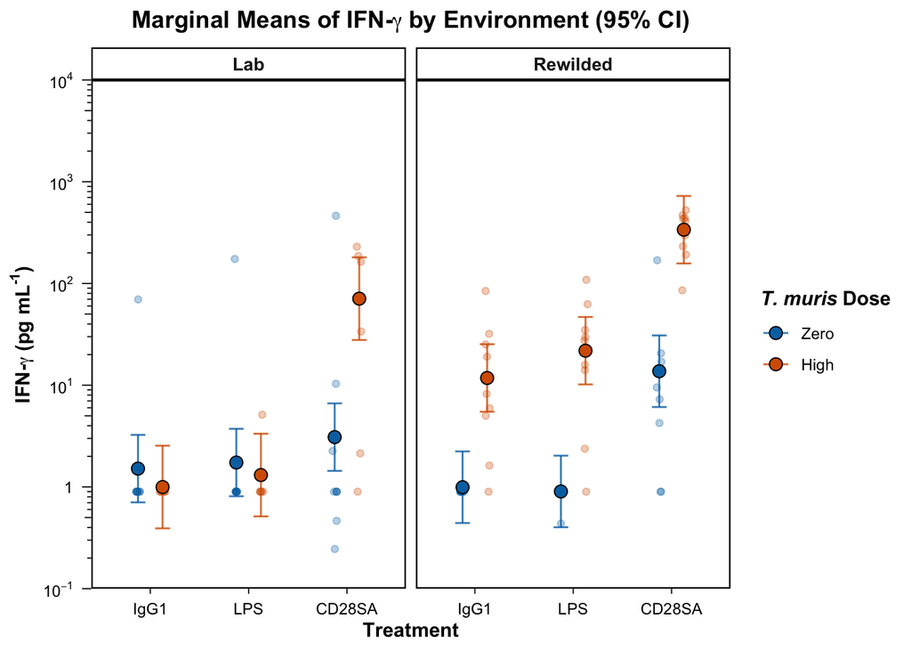

```r
emm_ifn_treatment_plot <- ggplot(emm_ifn_df) +
  geom_point(data = ifn_glmer_input %>%
               mutate(treatment = factor(treatment,
                                         levels = c("IgG", "LPS", "CD28")),
                      lab_or_rw = factor(lab_or_rw, levels = c("Lab", "RW")),
                      t_muris_dose = factor(t_muris_dose, levels = c("Zero", "High"))),
             aes(x = treatment,
                 y = mean_concentration,
                 color = t_muris_dose),
             position = position_jitterdodge(jitter.width = 0.1,
                                             dodge.width = 0.5),
             alpha = 0.3,
             size = 1.5) +
  geom_errorbar(aes(x = treatment,
                    ymin = asymp.LCL,
                    ymax = asymp.UCL,
                    color = t_muris_dose),
                width = 0.3,
                position = position_dodge(width = 0.5),
                alpha = 0.8) +
  geom_point(aes(x = treatment,
                 y = response,
                 fill = t_muris_dose),
             position = position_dodge(width = 0.5),
             alpha = 1,
             size = 3,
             shape = 21,
             color = "black") +
  scale_fill_manual(values = c("Zero" = color_dark_blue,
                               "High" = color_orange),
                    name = expression(bolditalic("T. muris") ~ bold("Dose"))) +
  scale_color_manual(values = c("Zero" = color_dark_blue,
                                "High" = color_orange),
                     name = expression(bolditalic("T. muris") ~ bold("Dose"))) +
  scale_y_continuous(name = expression(bold("IFN-" * gamma ~
                                              "(pg mL"^"-1" * ")")),
                     expand = expansion(mult = 0),
                     trans = "log10",
                     breaks = 10^seq(-1, 4),
                     labels = expression(10^-1, 1, 10^1,
                                         10^2, 10^3, 10^4),
                     limits = c(0.1, 10000),
                     guide = guide_axis_logticks(long = 1.8,
                                                mid = 1.3,
                                                short = 0.8,
                                                expanded = FALSE)) +
  scale_x_discrete(name = expression(bold("Treatment")),
                   labels = c("CD28" = "CD28SA",
                              "LPS" = "LPS",
                              "IgG" = "IgG1")) +
  facet_wrap(~ lab_or_rw,
             labeller = as_labeller(c("Lab" = "Lab",
                                      "RW"  = "Rewilded"))) +
  theme_minimal() +
  theme(strip.background = element_rect(fill = "white",
                                        color = "black",
                                        linewidth = 0.8),
        strip.text = element_text(size = 10,
                                  face = "bold"),
        panel.border = element_rect(color = "black",
                                    fill = NA,
                                    linewidth = 0.8),
        panel.grid = element_blank(),
        plot.title = element_text(hjust = 0.5, face = "bold"),
        axis.title.x = element_text(face = "bold"),
        axis.title.y = element_text(face = "bold"),
        axis.text = element_text(color = "black"),
        axis.ticks = element_line(color = "black",
                                  linewidth = 0.3),
        axis.ticks.length = unit(0.1, "cm")) +
  ggtitle(expression(bold("Marginal Means of IFN-" * gamma ~ "by Environment (95% CI)")))

emm_ifn_treatment_plot
```

```r
plot_saver("emm_ifn_treatment_plot.png",
           emm_ifn_treatment_plot)
svg_saver("emm_ifn_treatment_plot.svg",
          emm_ifn_treatment_plot)
```

# Plotting TNF faceted by treatment

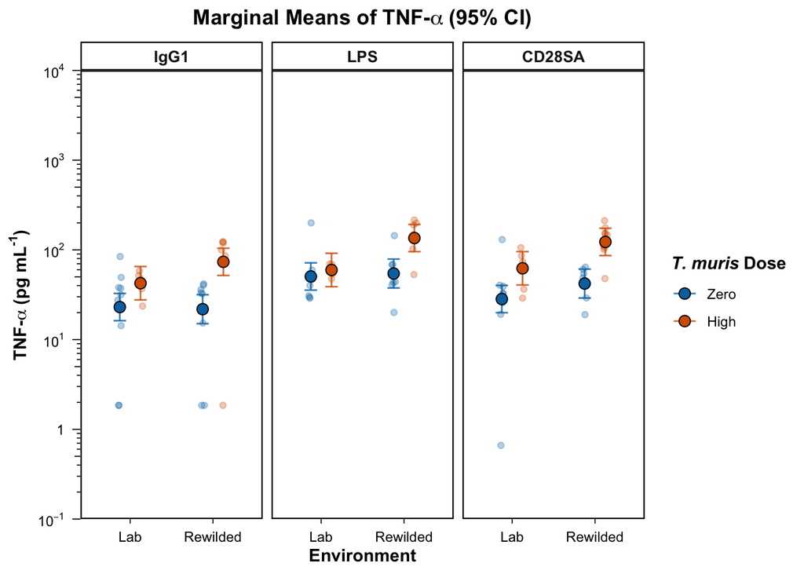

```r
emm_tnf_plot <- ggplot(emm_tnf_df) +
  geom_point(data = tnf_glmer_input %>%
               mutate(treatment = factor(treatment,
                                         levels = c("IgG", "LPS", "CD28")),
                      lab_or_rw = factor(lab_or_rw, levels = c("Lab", "RW")),
                      t_muris_dose = factor(t_muris_dose, levels = c("Zero", "High"))),
             aes(x = lab_or_rw,
                 y = mean_concentration,
                 color = t_muris_dose),
             position = position_jitterdodge(jitter.width = 0.1,
                                             dodge.width = 0.5),
             alpha = 0.3,
             size = 1.5) +
  geom_errorbar(aes(x = lab_or_rw,
                    ymin = asymp.LCL,
                    ymax = asymp.UCL,
                    color = t_muris_dose),
                width = 0.3,
                position = position_dodge(width = 0.5),
                alpha = 0.8) +
  geom_point(aes(x = lab_or_rw,
                 y = response,
                 fill = t_muris_dose),
             position = position_dodge(width = 0.5),
             alpha = 1,
             size = 3,
             shape = 21,
             color = "black") +
  scale_fill_manual(values = c("Zero" = color_dark_blue,
                               "High" = color_orange),
                    name = expression(bolditalic("T. muris") ~ bold("Dose"))) +
  scale_color_manual(values = c("Zero" = color_dark_blue,
                                "High" = color_orange),
                     name = expression(bolditalic("T. muris") ~ bold("Dose"))) +
  scale_y_continuous(name = expression(bold("TNF-" * alpha ~
                                              "(pg mL"^"-1" * ")")),
                     expand = expansion(mult = 0),
                     trans = "log10",
                     breaks = 10^seq(-1, 4),
                     labels = expression(10^-1, 1, 10^1,
                                         10^2, 10^3, 10^4),
                     limits = c(0.1, 10000),
                     guide = guide_axis_logticks(long = 1.8,
                                                mid = 1.3,
                                                short = 0.8,
                                                expanded = FALSE)) +
  scale_x_discrete(name = expression(bold("Environment")),
                   labels = c("Lab" = "Lab",
                              "RW"  = "Rewilded")) +
  facet_wrap(~ treatment,
             labeller = as_labeller(c("CD28" = "CD28SA",
                                      "LPS" = "LPS",
                                      "IgG" = "IgG1"))) +
  theme_minimal() +
  theme(strip.background = element_rect(fill = "white",
                                        color = "black",
                                        linewidth = 0.8),
        strip.text = element_text(size = 10,
                                  face = "bold"),
        panel.border = element_rect(color = "black",
                                    fill = NA,
                                    linewidth = 0.8),
        panel.grid = element_blank(),
        plot.title = element_text(hjust = 0.5, face = "bold"),
        axis.title.x = element_text(face = "bold"),
        axis.title.y = element_text(face = "bold"),
        axis.text = element_text(color = "black"),
        axis.ticks = element_line(color = "black",
                                  linewidth = 0.3),
        axis.ticks.length = unit(0.1, "cm")) +
  ggtitle(expression(bold("Marginal Means of TNF-" * alpha ~ "(95% CI)")))

emm_tnf_plot
```

```r
plot_saver("emm_tnf_plot.png",
           emm_tnf_plot)
svg_saver("emm_tnf_plot.svg",
          emm_tnf_plot)
```

# Plotting TNF emm in linear y axis. But, the log10 scale axis might be more consistent.

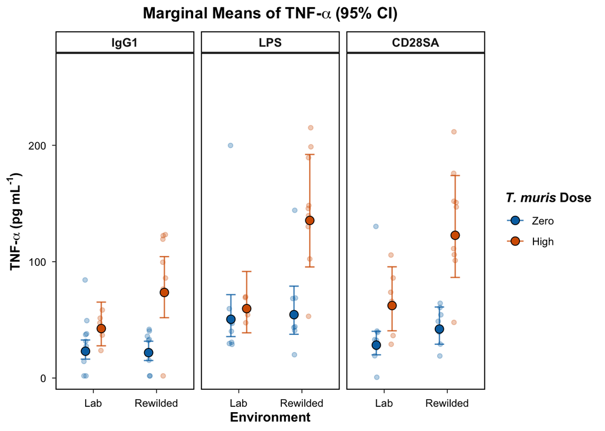

```r
emm_tnf_plot_linear <- ggplot(emm_tnf_df) +
  geom_point(data = tnf_glmer_input %>%
               mutate(treatment = factor(treatment,
                                         levels = c("IgG", "LPS", "CD28")),
                      lab_or_rw = factor(lab_or_rw, levels = c("Lab", "RW")),
                      t_muris_dose = factor(t_muris_dose, levels = c("Zero", "High"))),
             aes(x = lab_or_rw,
                 y = mean_concentration,
                 color = t_muris_dose),
             position = position_jitterdodge(jitter.width = 0.1,
                                             dodge.width = 0.5),
             alpha = 0.3,
             size = 1.5) +
  geom_errorbar(aes(x = lab_or_rw,
                    ymin = asymp.LCL,
                    ymax = asymp.UCL,
                    color = t_muris_dose),
                width = 0.3,
                position = position_dodge(width = 0.5),
                alpha = 0.8) +
  geom_point(aes(x = lab_or_rw,
                 y = response,
                 fill = t_muris_dose),
             position = position_dodge(width = 0.5),
             alpha = 1,
             size = 3,
             shape = 21,
             color = "black") +
  scale_fill_manual(values = c("Zero" = color_dark_blue,
                               "High" = color_orange),
                    name = expression(bolditalic("T. muris") ~ bold("Dose"))) +
  scale_color_manual(values = c("Zero" = color_dark_blue,
                                "High" = color_orange),
                     name = expression(bolditalic("T. muris") ~ bold("Dose"))) +
  scale_y_continuous(name = expression(bold("TNF-" * alpha ~
                                              "(pg mL"^"-1" * ")")),
                     expand = expansion(mult = c(0.05, 0.3))) +
  scale_x_discrete(name = expression(bold("Environment")),
                   labels = c("Lab" = "Lab",
                              "RW"  = "Rewilded")) +
  facet_wrap(~ treatment,
             labeller = as_labeller(c("CD28" = "CD28SA",
                                      "LPS" = "LPS",
                                      "IgG" = "IgG1"))) +
  theme_minimal() +
  theme(strip.background = element_rect(fill = "white",
                                        color = "black",
                                        linewidth = 0.8),
        strip.text = element_text(size = 10,
                                  face = "bold"),
        panel.border = element_rect(color = "black",
                                    fill = NA,
                                    linewidth = 0.8),
        panel.grid = element_blank(),
        plot.title = element_text(hjust = 0.5, face = "bold"),
        axis.title.x = element_text(face = "bold"),
        axis.title.y = element_text(face = "bold"),
        axis.text = element_text(color = "black"),
        axis.ticks = element_line(color = "black",
                                  linewidth = 0.3),
        axis.ticks.length = unit(0.1, "cm")) +
  ggtitle(expression(bold("Marginal Means of TNF-" * alpha ~ "(95% CI)")))

emm_tnf_plot_linear
```

```r
plot_saver("emm_tnf_plot_linear.png",
           emm_tnf_plot_linear)
svg_saver("emm_tnf_plot_linear.svg",
          emm_tnf_plot_linear)
```

# Plotting TNF faceted by dose

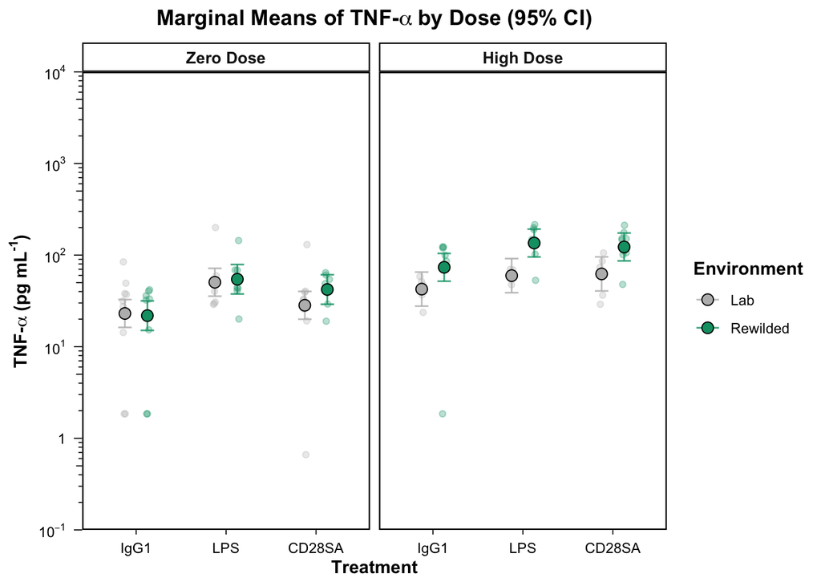

```r
emm_tnf_dose_plot <- ggplot(emm_tnf_df) +
  geom_point(data = tnf_glmer_input %>%
               mutate(treatment = factor(treatment,
                                         levels = c("IgG", "LPS", "CD28")),
                      lab_or_rw = factor(lab_or_rw, levels = c("Lab", "RW")),
                      t_muris_dose = factor(t_muris_dose, levels = c("Zero", "High"))),
             aes(x = treatment,
                 y = mean_concentration,
                 color = lab_or_rw),
             position = position_jitterdodge(jitter.width = 0.1,
                                             dodge.width = 0.5),
             alpha = 0.3,
             size = 1.5) +
  geom_errorbar(aes(x = treatment,
                    ymin = asymp.LCL,
                    ymax = asymp.UCL,
                    color = lab_or_rw),
                width = 0.3,
                position = position_dodge(width = 0.5),
                alpha = 0.8) +
  geom_point(aes(x = treatment,
                 y = response,
                 fill = lab_or_rw),
             position = position_dodge(width = 0.5),
             alpha = 1,
             size = 3,
             shape = 21,
             color = "black") +
  scale_fill_manual(values = c("Lab" = color_grey,
                               "RW"  = color_green),
                    name = expression(bold("Environment")),
                    labels = c("Lab" = "Lab",
                               "RW"  = "Rewilded")) +
  scale_color_manual(values = c("Lab" = color_grey,
                                "RW"  = color_green),
                     name = expression(bold("Environment")),
                     labels = c("Lab" = "Lab",
                                "RW"  = "Rewilded")) +
  scale_y_continuous(name = expression(bold("TNF-" * alpha ~
                                              "(pg mL"^"-1" * ")")),
                     expand = expansion(mult = 0),
                     trans = "log10",
                     breaks = 10^seq(-1, 4),
                     labels = expression(10^-1, 1, 10^1,
                                         10^2, 10^3, 10^4),
                     limits = c(0.1, 10000),
                     guide = guide_axis_logticks(long = 1.8,
                                                mid = 1.3,
                                                short = 0.8,
                                                expanded = FALSE)) +
  scale_x_discrete(name = expression(bold("Treatment")),
                   labels = c("CD28" = "CD28SA",
                              "LPS" = "LPS",
                              "IgG" = "IgG1")) +
  facet_wrap(~ t_muris_dose,
             labeller = as_labeller(c("Zero" = "Zero Dose",
                                      "High" = "High Dose"))) +
  theme_minimal() +
  theme(strip.background = element_rect(fill = "white",
                                        color = "black",
                                        linewidth = 0.8),
        strip.text = element_text(size = 10,
                                  face = "bold"),
        panel.border = element_rect(color = "black",
                                    fill = NA,
                                    linewidth = 0.8),
        panel.grid = element_blank(),
        plot.title = element_text(hjust = 0.5, face = "bold"),
        axis.title.x = element_text(face = "bold"),
        axis.title.y = element_text(face = "bold"),
        axis.text = element_text(color = "black"),
        axis.ticks = element_line(color = "black",
                                  linewidth = 0.3),
        axis.ticks.length = unit(0.1, "cm")) +
  ggtitle(expression(bold("Marginal Means of TNF-" * alpha ~ "by Dose (95% CI)")))

emm_tnf_dose_plot
```

```r
plot_saver("emm_tnf_dose_plot.png",
           emm_tnf_dose_plot)
svg_saver("emm_tnf_dose_plot.svg",
          emm_tnf_dose_plot)
```